# Node analysis of social connectedness and health inequalities

In this notebook, we run the analysis (modelling + diagnostics) for linking social connectedness to health outcomes.

### Relevant libraries

```r
library(tidyverse)    # Data wrangling
library(sf)           # Spatial analysis
library(caret)        # For machine learning and preprocessing
library(spdep)        # For spatial analysis
library(spatialreg)   # For spatial regressions
library(olsrr)        # For OLS residual diagnostics
library(lme4)         # For random effects models
library(lmerTest)     # For approximated p-values in mixed models
library(ggplot2)      # Visualizations

library(sjPlot)       # for tab_model function

select <- dplyr::select
```

### Relevant data

```r
# Map data
afr_dat <- st_read(dsn = "/Users/tillkoebe/Documents/GitHub/health_inequalities/combined_dataset/GADM_1_geometries.gpkg") %>%
  st_make_valid() %>%
  st_transform(4326)
# Social Connectedness Index
sci <- read.csv("/Users/tillkoebe/Documents/GitHub/health_inequalities/external_dataset/sci_indices.csv") %>%
  distinct(user_loc, .keep_all = T)

# Worldpop covariates
wp <- read.csv("/Users/tillkoebe/Documents/GitHub/health_inequalities/external_dataset/wp.csv") %>%
  distinct(GID_1, .keep_all = T)

# Human Development Index
hdi <- read.csv("/Users/tillkoebe/Documents/GitHub/health_inequalities/external_dataset/hdi.csv") %>%
  distinct(GID_1, .keep_all = T)

# Facebook covariates
fb <- read.csv("/Users/tillkoebe/Documents/GitHub/health_inequalities/external_dataset/fb.csv") %>%
  distinct(GID_1, .keep_all = T)

# DHS data
dhs <- read.csv('/Users/tillkoebe/Documents/GitHub/health_inequalities/external_dataset/dhs_health.csv')

# Afrobarometer
afr <- read.csv('/Users/tillkoebe/Documents/GitHub/health_inequalities/external_dataset/afrobarometer.csv') %>%
  distinct(GID_1, .keep_all = T)

# Raw SCI
sci_raw <- read.csv("/Users/tillkoebe/Documents/Data/SCI/sci_gadm1.tsv", sep = "\t") %>%
  filter(user_loc %in% unique(dhs$GID_1),
         fr_loc %in% unique(dhs$GID_1))
```

### Defining targets and controls

Let’s define our targets and controls:

```r
### Define targets
dhs_targets <- dhs %>%
  select(rh_anc_pv:we_num_justifydv) %>%
  select(starts_with(c('rh', 'ch', 'nt', 'fp'))) %>%
  select(-fp_message_noneof4) %>%
  names()

### Define controls
dhs_controls <- c(
  'poorest',
  'poorer',
  'middle',
  'richer',
  'richest',
  'female',
  'secondary_or_higher',
  'has_mobile_phone_yes',
  'rural',
  "X.0.15.",
  "X.15.20.",
  "X.20.25.",
  "X.25.30.",
  "X.30.35.",
  "X.35.40.",
  "X.40.45.",
  "X.45.50.",
  "X.50.inf."
)

sci_controls <- c('Mean_dist_to_SCI_km', # Average distance of friendships
                  'Median_dist_to_SCI_km', # Average distance of friendships
                  'Std_dist_to_SCI_km', # Clustering measure of friendships across distances
                  'Total_dist_to_SCI_km', # Total distance of friendships
                  'Ratio_selfloop_to_country', # Share of local friendships within the same country
                  'Ratio_selfloop_to_africa', # Share of local friendships that stay within Africa
                  'Ratio_selfloop_to_all_sci', # Share of local friendships of all friendships
                  'Average_distance_of_friendships_km',
                  'Mean_SCI_without_Self', # Average probability of friendships with other regions
                  'Median_SCI_without_Self', # Average probability of friendships with other regions
                  'Std_SCI_without_Self', # Clustering measure for the probability of friendships with other regions
                  'Mean_SCI_with_Self', # Average probability of friendships across all regions
                  'Median_SCI_with_Self', # Average probability of friendships across all regions
                  'Std_SCI_with_Self', # Average probability of friendships across all regions
                  'Mean_friendship', # Average friendships per FB users
                  'Median_friendship', # Average friendships per FB users
                  'Std_friendship', # Clustering measure for friendships per FB user
                  'Total_friendship', # Sum of friendships per FB user
                  'Ratio_SCI_low_hi_africa', # Share of friendships to regions with a low health index
                  'Ratio_SCI_middle_hi_africa', # Share of friendships to regions with a medium health index
                  'Ratio_SCI_high_hi_africa' # Share of friendships to regions with a high health index
)

hdi_controls <- c('HDI')

wp_controls <- c(
  'Mean_of_Night_Light',
  'Std_of_Night_Light',
  'Mean_distance_to_major_rd_intersection',
  'Std_distance_to_major_rd_intersection',
  'Mean_distance_to_major_rd',
  'Std_distance_to_major_rd',
  "Mean_distance_to_inland_water",
  "Std_distance_to_inland_water",
  "Mean_built_settlement_growth",
  "Std_built_settlement_growth")

fb_controls <- c('fb_rwi_mean',
                 'fb_rwi_mean_pop_wght',
                 'FB_pntr_15to49_female',
                 'FB_pntr_15to49_all')

afr_controls <- c('trpar',
                  'trtax',
                  'trgov',
                  'trlaw',
                  'trgen',
                  'trrel',
                  'trnei',
                  'tracq')
```

We then merge datasets:

```r
dat <- dhs %>%
  select(GID_1,
         all_of(dhs_targets),
         all_of(dhs_controls)) %>%
  left_join(sci %>%
              select(GID_1 = user_loc,
                     all_of(sci_controls)),
            by = 'GID_1') %>%
  left_join(hdi %>%
              select(GID_1,
                     all_of(hdi_controls)),
            by = 'GID_1') %>%
  left_join(wp %>%
              drop_na(GID_1) %>%
              select(GID_1,
                     all_of(wp_controls)),
            by = 'GID_1') %>%
  left_join(fb %>%
              select(GID_1,
                     all_of(fb_controls)),
            by = 'GID_1') %>%
  left_join(afr %>%
              select(GID_1,
                     all_of(afr_controls)),
            by = 'GID_1') %>%
  mutate(iso3 = substr(GID_1, 1, 3))
```

Here an overview of the variables we now have in our dataset:

```r
dim(dat)
```

```
## [1] 446  85
```

```r
names(dat)
```

```
##  [1] "GID_1"
##  [2] "rh_anc_pv"
##  [3] "rh_anc_pvskill"
##  [4] "rh_anc_numvs"
##  [5] "rh_anc_4vs"
##  [6] "rh_anc_moprg"
##  [7] "rh_prob_permit"
##  [8] "rh_prob_money"
##  [9] "rh_prob_dist"
## [10] "rh_prob_alone"
## [11] "rh_prob_minone"
## [12] "ch_allvac_either"
## [13] "ch_novac_either"
## [14] "nt_bf_ever"
## [15] "nt_bf_start_1hr"
```

[output cut: 70 more lines]

A description of the variables can be found [here](https://drive.google.com/file/d/1vCgciS4_zMz6hs5SoRl8_5yxP5drHt1C/view?usp=sharing).

### Summary statistics

```r
dat %>%
  select(all_of(dhs_targets)) %>%
  summary()
```

```
##    rh_anc_pv      rh_anc_pvskill      rh_anc_numvs      rh_anc_4vs
##  Min.   :0.3357   Min.   :0.005495   Min.   :0.6043   Min.   :0.1260
##  1st Qu.:0.9031   1st Qu.:0.584829   1st Qu.:0.9507   1st Qu.:0.4589
##  Median :0.9679   Median :0.910262   Median :0.9719   Median :0.5680
##  Mean   :0.9185   Mean   :0.734630   Mean   :0.9574   Mean   :0.5659
##  3rd Qu.:0.9863   3rd Qu.:0.966953   3rd Qu.:0.9835   3rd Qu.:0.6792
##  Max.   :1.0000   Max.   :1.000000   Max.   :1.0000   Max.   :0.9530
##   rh_anc_moprg    rh_prob_permit     rh_prob_money      rh_prob_dist
##  Min.   :0.2222   Min.   :0.003401   Min.   :0.06373   Min.   :0.02428
##  1st Qu.:0.5111   1st Qu.:0.041671   1st Qu.:0.29520   1st Qu.:0.22177
##  Median :0.6544   Median :0.087403   Median :0.46835   Median :0.35163
##  Mean   :0.6322   Mean   :0.145536   Mean   :0.45843   Mean   :0.35213
##  3rd Qu.:0.7730   3rd Qu.:0.213091   3rd Qu.:0.61624   3rd Qu.:0.47083
##  Max.   :0.9603   Max.   :0.881752   Max.   :0.93076   Max.   :0.89635
##  rh_prob_alone    rh_prob_minone    ch_allvac_either ch_novac_either
##  Min.   :0.0000   Min.   :0.08649   Min.   :0.0000   Min.   :0.00000
##  1st Qu.:0.1065   1st Qu.:0.43603   1st Qu.:0.4232   1st Qu.:0.00000
##  Median :0.1840   Median :0.59744   Median :0.6159   Median :0.02303
##  Mean   :0.2080   Mean   :0.56671   Mean   :0.5852   Mean   :0.06176
##  3rd Qu.:0.2909   3rd Qu.:0.71579   3rd Qu.:0.7647   3rd Qu.:0.07460
##  Max.   :0.8788   Max.   :0.96135   Max.   :0.9766   Max.   :0.65909
##    nt_bf_ever     nt_bf_start_1hr   nt_bf_start_1day  nt_bf_prelac
##  Min.   :0.5493   Min.   :0.01538   Min.   :0.3463   Min.   :0.0000
##  1st Qu.:0.9629   1st Qu.:0.40126   1st Qu.:0.8088   1st Qu.:0.0928
##  Median :0.9754   Median :0.58237   Median :0.9016   Median :0.2407
##  Mean   :0.9662   Mean   :0.56276   Mean   :0.8409   Mean   :0.3529
##  3rd Qu.:0.9849   3rd Qu.:0.72406   3rd Qu.:0.9489   3rd Qu.:0.4579
##  Max.   :1.0000   Max.   :0.96183   Max.   :1.0000   Max.   :0.9970
##    nt_bottle        fp_know_any      fp_know_mod      fp_know_trad
##  Min.   :0.00000   Min.   :0.3943   Min.   :0.3921   Min.   :0.1068
##  1st Qu.:0.04986   1st Qu.:0.9417   1st Qu.:0.9392   1st Qu.:0.5969
##  Median :0.10050   Median :0.9821   Median :0.9815   Median :0.7362
##  Mean   :0.14461   Mean   :0.9533   Mean   :0.9505   Mean   :0.6905
##  3rd Qu.:0.19243   3rd Qu.:0.9929   3rd Qu.:0.9922   3rd Qu.:0.8260
##  Max.   :0.87118   Max.   :1.0000   Max.   :1.0000   Max.   :0.9620
##  fp_message_noneof3
##  Min.   :0.02488
##  1st Qu.:0.36362
##  Median :0.54535
##  Mean   :0.52154
##  3rd Qu.:0.69448
##  Max.   :0.92520
```

Seems that quite a few, especially of the most interesting variables imo (rh_anc_pv, rh_anc_pvskill, ch_allvac_either, ch_novac_either, fp_know_mod, nt_bf_ever, fp_message_noneof3) are quite skewed. Let’s visualize as density plots.

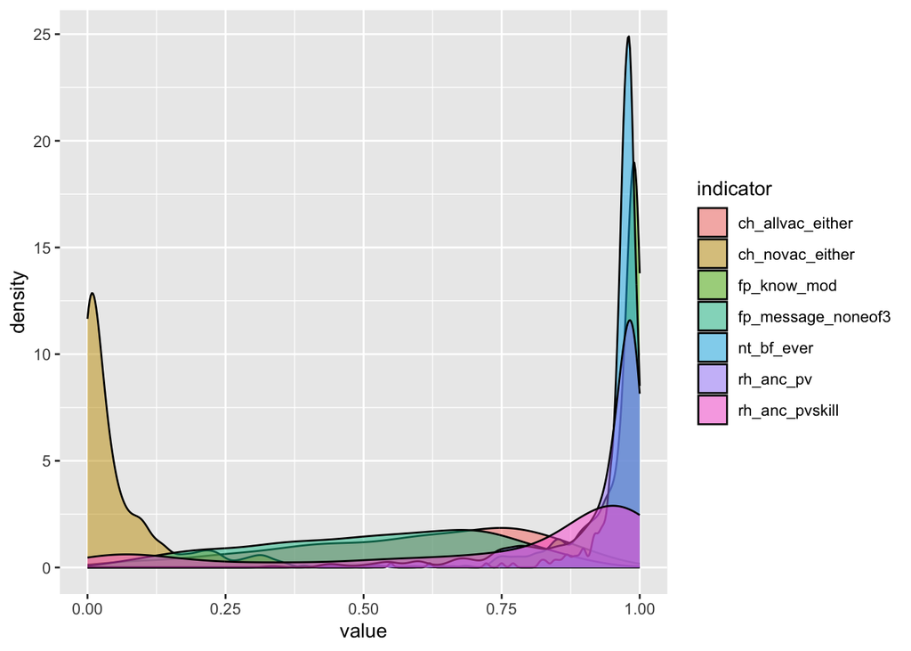

```r
dat %>%
  select(ch_allvac_either, ch_novac_either, rh_anc_pv, rh_anc_pvskill, fp_know_mod, nt_bf_ever, fp_message_noneof3) %>%
  pivot_longer(cols = everything(),names_to = "indicator", values_to = "value") %>%
  ggplot(aes(x = value, fill = indicator)) + geom_density(alpha = 0.5)
```

Yes, they are. We may need to log-transform them. We add a small to the zeros to avoid -inf values.

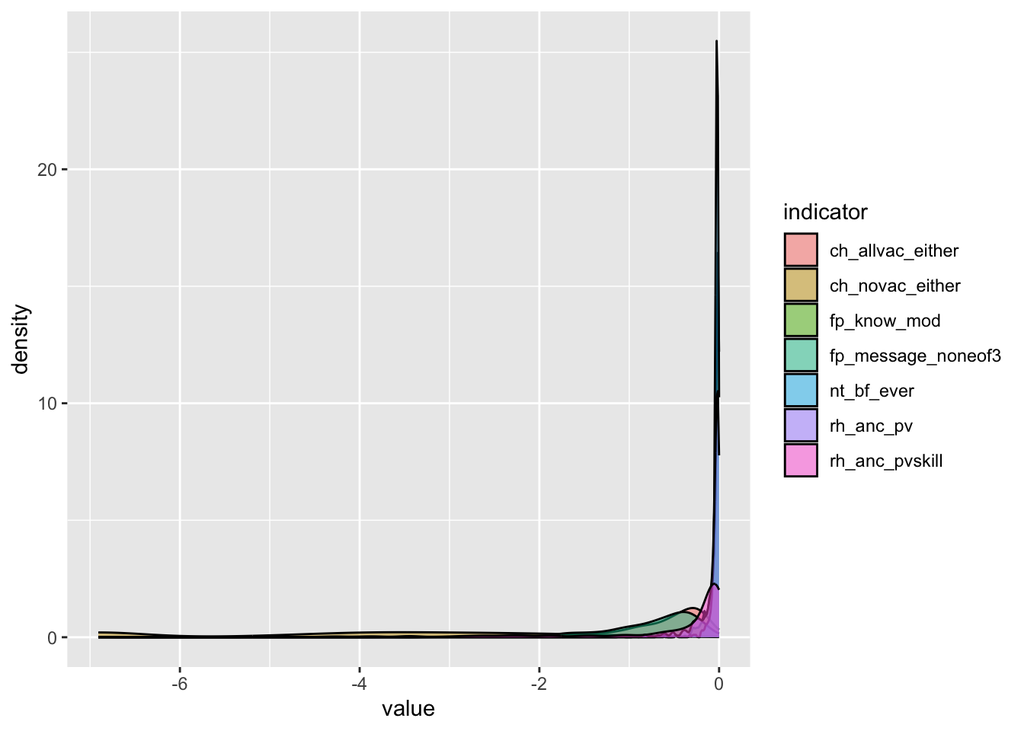

```r
dat %>%
  mutate(across(all_of(dhs_targets), ~ ifelse(.x == 0, 0.001, .x)),
         across(all_of(dhs_targets), ~ log(.x))) %>%
  select(ch_allvac_either, ch_novac_either, rh_anc_pv, rh_anc_pvskill, fp_know_mod, nt_bf_ever, fp_message_noneof3) %>%
  pivot_longer(cols = everything(),names_to = "indicator", values_to = "value") %>%
  ggplot(aes(x = value, fill = indicator)) + geom_density(alpha = 0.5)
```

That doesn’t look much better. We have too many values close to zero. What about arcsine-transformation?

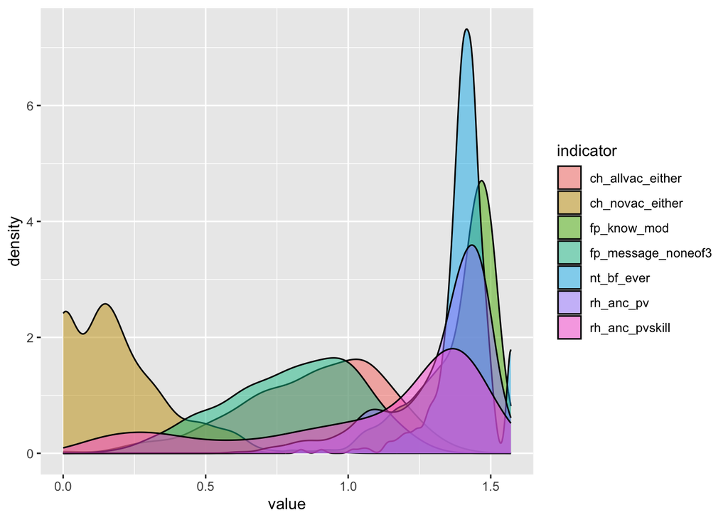

```r
dat %>%
  mutate(across(all_of(dhs_targets), ~ asin(sqrt(.x)))) %>%
  select(ch_allvac_either, ch_novac_either, rh_anc_pv, rh_anc_pvskill, fp_know_mod, nt_bf_ever, fp_message_noneof3) %>%
  pivot_longer(cols = everything(),names_to = "indicator", values_to = "value") %>%
  ggplot(aes(x = value, fill = indicator)) + geom_density(alpha = 0.5)
```

That looks much better. We may need to consider arcsine-transformation of our response variables then. But for now, let’s look at the SCI indicators:

```r
dat %>%
  select(all_of(sci_controls)) %>%
  summary()
```

```
##  Mean_dist_to_SCI_km Median_dist_to_SCI_km Std_dist_to_SCI_km
##  Min.   :2593        Min.   :2400          Min.   :1081
##  1st Qu.:2828        1st Qu.:2805          1st Qu.:1586
##  Median :3105        Median :3038          Median :1776
##  Mean   :3291        Mean   :3232          Mean   :1747
##  3rd Qu.:3610        3rd Qu.:3581          3rd Qu.:1994
##  Max.   :4964        Max.   :4688          Max.   :2316
##  NA's   :2           NA's   :2             NA's   :2
##  Total_dist_to_SCI_km Ratio_selfloop_to_country Ratio_selfloop_to_africa
##  Min.   :1815197      Min.   :0.01797           Min.   :0.01734
##  1st Qu.:1979904      1st Qu.:0.36209           1st Qu.:0.30389
##  Median :2173591      Median :0.53565           Median :0.46617
##  Mean   :2303824      Mean   :0.50803           Mean   :0.45959
##  3rd Qu.:2526835      3rd Qu.:0.67459           3rd Qu.:0.61919
##  Max.   :3474946      Max.   :0.92296           Max.   :0.88807
##  NA's   :2            NA's   :2                 NA's   :2
##  Ratio_selfloop_to_all_sci Average_distance_of_friendships_km
##  Min.   :0.01702           Min.   :  50.93
##  1st Qu.:0.29193           1st Qu.: 191.99
##  Median :0.45503           Median : 314.76
##  Mean   :0.44694           Mean   : 357.07
##  3rd Qu.:0.60843           3rd Qu.: 466.19
##  Max.   :0.88240           Max.   :1831.52
##  NA's   :2                 NA's   :2
##  Mean_SCI_without_Self Median_SCI_without_Self Std_SCI_without_Self
##  Min.   :   88.61      Min.   :  1.00          Min.   :   868.5
##  1st Qu.:  595.11      1st Qu.: 10.00          1st Qu.: 12905.9
##  Median : 1159.91      Median : 15.00          Median : 23541.5
##  Mean   : 1879.63      Mean   : 19.78          Mean   : 44061.1
##  3rd Qu.: 2867.00      3rd Qu.: 25.00          3rd Qu.: 58857.5
##  Max.   :16206.18      Max.   :129.00          Max.   :687652.8
##  NA's   :2             NA's   :2               NA's   :2
##  Mean_SCI_with_Self Median_SCI_with_Self Std_SCI_with_Self Mean_friendship
##  Min.   :  123.2    Min.   :  1.00       Min.   :   1869   Min.   :  1218
##  1st Qu.: 1149.8    1st Qu.: 10.00       1st Qu.:  38714   1st Qu.: 12568
##  Median : 2172.3    Median : 15.00       Median :  91830   Median : 24258
##  Mean   : 4040.6    Mean   : 19.79       Mean   : 202061   Mean   : 45556
##  3rd Qu.: 5367.2    3rd Qu.: 25.00       3rd Qu.: 235242   3rd Qu.: 60073
##  Max.   :35562.4    Max.   :129.00       Max.   :2001258   Max.   :405440
##  NA's   :2          NA's   :2            NA's   :2         NA's   :2
##  Median_friendship Std_friendship    Total_friendship
##  Min.   :  64.0    Min.   :   6074   Min.   :   852373
##  1st Qu.: 369.6    1st Qu.: 130176   1st Qu.:  8797735
##  Median : 543.0    Median : 308747   Median : 16980465
##  Mean   : 566.6    Mean   : 681487   Mean   : 31888827
##  3rd Qu.: 724.2    3rd Qu.: 793267   3rd Qu.: 42050804
##  Max.   :1936.0    Max.   :6754138   Max.   :283807853
##  NA's   :2         NA's   :2         NA's   :2
##  Ratio_SCI_low_hi_africa Ratio_SCI_middle_hi_africa Ratio_SCI_high_hi_africa
##  Min.   :0.02021         Min.   :0.0001733          Min.   :0.0003387
##  1st Qu.:0.95671         1st Qu.:0.0027775          1st Qu.:0.0028563
##  Median :0.98059         Median :0.0057070          Median :0.0068452
##  Mean   :0.93571         Mean   :0.0386260          Mean   :0.0165341
##  3rd Qu.:0.99152         3rd Qu.:0.0141310          3rd Qu.:0.0146948
##  Max.   :0.99908         Max.   :0.9785693          Max.   :0.2990487
##  NA's   :2               NA's   :2                  NA's   :2
```

Some of the SCI has very high values (recall Meta multiplies the relative probability of friendship links between two regions by one billion). It makes sense to scale them. But let’s first look at the other controls as well:

For the DHS

```r
dat %>%
  select(all_of(dhs_controls)) %>%
  summary()
```

```
##     poorest            poorer           middle           richer
##  Min.   :0.00000   Min.   :0.0000   Min.   :0.0000   Min.   :0.0007093
##  1st Qu.:0.08153   1st Qu.:0.1481   1st Qu.:0.1602   1st Qu.:0.1273870
##  Median :0.18361   Median :0.2107   Median :0.2091   Median :0.1770596
##  Mean   :0.22212   Mean   :0.2034   Mean   :0.2010   Mean   :0.1934383
##  3rd Qu.:0.31347   3rd Qu.:0.2632   3rd Qu.:0.2542   3rd Qu.:0.2556453
##  Max.   :0.88522   Max.   :0.4509   Max.   :0.4423   Max.   :0.5672131
##
##     richest             female       secondary_or_higher has_mobile_phone_yes
##  Min.   :0.002913   Min.   :0.4611   Min.   :0.006897    Min.   :0.1210
##  1st Qu.:0.073781   1st Qu.:0.5041   1st Qu.:0.040700    1st Qu.:0.6587
##  Median :0.131622   Median :0.5134   Median :0.059684    Median :0.8233
##  Mean   :0.180084   Mean   :0.5149   Mean   :0.066103    Mean   :0.7754
##  3rd Qu.:0.210614   3rd Qu.:0.5258   3rd Qu.:0.087683    3rd Qu.:0.9075
##  Max.   :0.999291   Max.   :0.5805   Max.   :0.176901    Max.   :0.9973
##                                      NA's   :19
##      rural           X.0.15.          X.15.20.          X.20.25.
##  Min.   :0.0000   Min.   :0.2383   Min.   :0.05567   Min.   :0.04034
##  1st Qu.:0.5973   1st Qu.:0.4218   1st Qu.:0.08781   1st Qu.:0.06667
##  Median :0.7326   Median :0.4677   Median :0.09623   Median :0.07392
##  Mean   :0.6674   Mean   :0.4565   Mean   :0.09662   Mean   :0.07553
##  3rd Qu.:0.8285   3rd Qu.:0.5015   3rd Qu.:0.10556   3rd Qu.:0.08265
##  Max.   :1.0000   Max.   :0.5912   Max.   :0.15226   Max.   :0.14515
##
##     X.25.30.          X.30.35.          X.35.40.          X.40.45.
##  Min.   :0.03734   Min.   :0.03626   Min.   :0.02940   Min.   :0.01990
##  1st Qu.:0.05973   1st Qu.:0.04997   1st Qu.:0.04471   1st Qu.:0.03440
##  Median :0.06638   Median :0.05717   Median :0.05021   Median :0.03884
##  Mean   :0.06836   Mean   :0.05846   Mean   :0.05135   Mean   :0.04044
##  3rd Qu.:0.07448   3rd Qu.:0.06451   3rd Qu.:0.05710   3rd Qu.:0.04468
##  Max.   :0.15186   Max.   :0.12219   Max.   :0.09831   Max.   :0.08109
##
##     X.45.50.         X.50.inf.
##  Min.   :0.01396   Min.   :0.05899
##  1st Qu.:0.02670   1st Qu.:0.09939
##  Median :0.03095   Median :0.11517
##  Mean   :0.03230   Mean   :0.12031
##  3rd Qu.:0.03708   3rd Qu.:0.13678
##  Max.   :0.06963   Max.   :0.25000
##
```

They all seem to be ok. For Worldpop covariates:

```r
dat %>%
  select(all_of(wp_controls)) %>%
  summary()
```

```
##  Mean_of_Night_Light Std_of_Night_Light  Mean_distance_to_major_rd_intersection
##  Min.   :2.462e+37   Min.   :8.816e+37   Min.   :  0.5205
##  1st Qu.:1.640e+38   1st Qu.:1.655e+38   1st Qu.:  8.3068
##  Median :1.921e+38   Median :1.688e+38   Median : 15.3836
##  Mean   :1.994e+38   Mean   :1.661e+38   Mean   : 35.5574
##  3rd Qu.:2.307e+38   3rd Qu.:1.699e+38   3rd Qu.: 36.0852
##  Max.   :3.367e+38   Max.   :1.701e+38   Max.   :396.9001
##  Std_distance_to_major_rd_intersection Mean_distance_to_major_rd
##  Min.   :  0.3647                      Min.   :  0.3001
##  1st Qu.:  5.5012                      1st Qu.:  3.0909
##  Median : 10.5779                      Median :  5.5624
##  Mean   : 22.4304                      Mean   : 10.6739
##  3rd Qu.: 24.8916                      3rd Qu.: 11.0024
##  Max.   :262.0437                      Max.   :187.2493
##  Std_distance_to_major_rd Mean_distance_to_inland_water
##  Min.   :  0.2307         Min.   :  0.106
##  1st Qu.:  2.4784         1st Qu.:  9.034
##  Median :  4.3715         Median : 13.440
##  Mean   :  8.2616         Mean   : 20.108
##  3rd Qu.:  9.0761         3rd Qu.: 20.081
##  Max.   :134.5612         Max.   :318.284
##  Std_distance_to_inland_water Mean_built_settlement_growth
##  Min.   :  0.00456            Min.   : 77.84
##  1st Qu.:  6.01280            1st Qu.:244.43
##  Median :  9.17111            Median :252.77
##  Mean   : 13.45427            Mean   :243.50
##  3rd Qu.: 13.41049            3rd Qu.:254.31
##  Max.   :212.58834            Max.   :254.99
##  Std_built_settlement_growth
##  Min.   : 66.04
##  1st Qu.:124.05
##  Median :126.47
##  Mean   :124.46
##  3rd Qu.:127.26
##  Max.   :127.50
```

They all look ok, too, although one could consider scaling them as well. For Facebook covariates:

```r
dat %>%
  select(all_of(fb_controls)) %>%
  summary()
```

```
##   fb_rwi_mean      fb_rwi_mean_pop_wght FB_pntr_15to49_female
##  Min.   :-0.7078   Min.   :-0.54231     Min.   :0.00000
##  1st Qu.:-0.4275   1st Qu.:-0.20060     1st Qu.:0.01364
##  Median :-0.3246   Median :-0.04657     Median :0.05612
##  Mean   :-0.2326   Mean   : 0.05823     Mean   :0.13895
##  3rd Qu.:-0.1220   3rd Qu.: 0.16987     3rd Qu.:0.14734
##  Max.   : 1.3804   Max.   : 1.57529     Max.   :1.00000
##                                         NA's   :1
##  FB_pntr_15to49_all
##  Min.   :0.00000
##  1st Qu.:0.02380
##  Median :0.08262
##  Mean   :0.16928
##  3rd Qu.:0.17680
##  Max.   :1.00000
##  NA's   :1
```

For Afrobarometer covariates

```r
dat %>%
  select(all_of(afr_controls)) %>%
  summary()
```

```
##      trpar            trtax           trgov            trlaw
##  Min.   :0.4294   Min.   :0.359   Min.   :0.3767   Min.   :0.7016
##  1st Qu.:1.3442   1st Qu.:1.173   1st Qu.:1.3040   1st Qu.:1.4915
##  Median :1.7317   Median :1.428   Median :1.6028   Median :1.8059
##  Mean   :1.7032   Mean   :1.441   Mean   :1.5781   Mean   :1.7791
##  3rd Qu.:2.0391   3rd Qu.:1.670   3rd Qu.:1.8534   3rd Qu.:2.0772
##  Max.   :2.7120   Max.   :2.537   Max.   :2.5308   Max.   :2.8944
##  NA's   :201      NA's   :195     NA's   :195      NA's   :195
##      trgen             trrel           trnei            tracq
##  Min.   :0.01032   Min.   :0.718   Min.   :0.4903   Min.   :0.2160
##  1st Qu.:0.09707   1st Qu.:2.137   1st Qu.:1.4348   1st Qu.:0.9618
##  Median :0.15973   Median :2.480   Median :1.8109   Median :1.2783
##  Mean   :0.21186   Mean   :2.434   Mean   :1.7992   Mean   :1.3157
##  3rd Qu.:0.27744   3rd Qu.:2.826   3rd Qu.:2.2414   3rd Qu.:1.6225
##  Max.   :0.71728   Max.   :3.000   Max.   :2.8904   Max.   :2.4243
##  NA's   :195       NA's   :195     NA's   :195      NA's   :195
```

For HDI covariates

```r
dat %>%
  select(all_of(hdi_controls)) %>%
  summary()
```

```
##       HDI
##  Min.   :0.3310
##  1st Qu.:0.4728
##  Median :0.5240
##  Mean   :0.5325
##  3rd Qu.:0.5920
##  Max.   :0.7510
##  NA's   :138
```

### Preprocessing

Before we start looking at spatial autocorrelation and other modelling outcomes, we need to prepare our final dataset.

First, we center and scale SCI and WP features

```r
# Center and scale SCI variables
dat <- dat %>%
  mutate(across(all_of(sci_controls), ~ scale(.x, scale = T)),
         across(all_of(wp_controls), ~ scale(.x, scale = T))
         )
```

Then, we select only the variables we need and drop nas.

```r
temp <- dat %>%
  select(GID_1,
         all_of(dhs_targets),
         all_of(dhs_controls),
         all_of(sci_controls),
         all_of(fb_controls),
         # afr_controls,
         # hdi_controls,
         all_of(wp_controls),
         iso3) %>%
  drop_na
```

Now, we can align the map to the final dataset.

```r
geodat <- afr_dat %>%
  left_join(temp,
            by = 'GID_1') %>%
  drop_na(all_of(dhs_targets)) %>%
  st_make_valid()
```

### Spatial autocorrelation in health outcomes

```r
set.ZeroPolicyOption(TRUE)
```

```
## [1] FALSE
```

```r
moran_dep <- data.frame()

# loop through a distance vector d ranging from 50 to 2000 m
dist_start = 1
dist_stop = 50
dist_step = 1

for (d in seq(dist_start, dist_stop, dist_step)) {

  nb_w <- geodat %>%
    st_centroid() %>%
    dnearneigh(., d1 = 0, d2 = d, longlat = T) %>%
    nb2listw(., style = "W", zero.policy = TRUE)

  for(i in c('ch_allvac_either', 'ch_novac_either', 'rh_anc_pv', 'rh_anc_pvskill', 'fp_know_mod', 'nt_bf_ever', 'fp_message_noneof3')){

  moran_test <- moran.mc(asin(sqrt(temp[[i]])), nb_w, nsim = 999, zero.policy = TRUE)

  moran_dep <- data.frame(moran_I = moran_test$statistic,
                             dep_var = i,
                             distance = d) %>%
    bind_rows(moran_dep)

  }
  print(paste0(d, ' of ',dist_stop))
}
```

```
## [1] "1 of 50"
## [1] "2 of 50"
## [1] "3 of 50"
## [1] "4 of 50"
## [1] "5 of 50"
## [1] "6 of 50"
## [1] "7 of 50"
## [1] "8 of 50"
## [1] "9 of 50"
## [1] "10 of 50"
## [1] "11 of 50"
## [1] "12 of 50"
## [1] "13 of 50"
## [1] "14 of 50"
## [1] "15 of 50"
```

[output cut: 35 more lines]

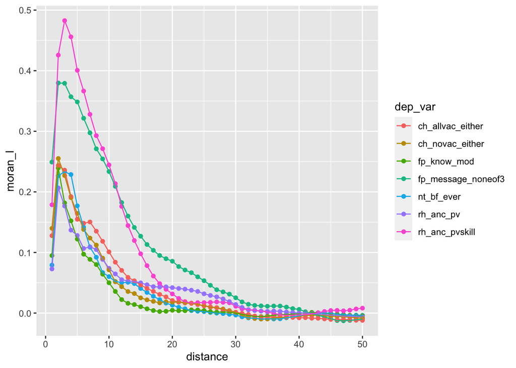

```r
ggplot(moran_dep, aes(x = distance, y = moran_I, col=dep_var)) +
  geom_point() +
  geom_line()
```

It seems that we have some strong spatial autocorrelation in the dependent variables. Let’s go into the modelling and check if the autocorrelation also persists in the residuals of our models.

### Modelling

We first pick our controls based onnarrative/theory.

```r
controls <- c('Mean_SCI_without_Self +
                Ratio_selfloop_to_africa +
                Ratio_SCI_low_hi_africa +
                Ratio_SCI_high_hi_africa +
                poorest +
                poorer +
                female +
                secondary_or_higher +
                has_mobile_phone_yes +
                rural +
                X.0.15. +
                X.15.20. +
                X.20.25. +
                X.25.30. +
                X.30.35. +
                X.35.40. +
                X.40.45. +
                X.45.50. +
                X.50.inf. +
                Mean_of_Night_Light +
                Mean_distance_to_major_rd +
                FB_pntr_15to49_all +
                female:has_mobile_phone_yes +
                female:Mean_SCI_without_Self +
                has_mobile_phone_yes:Mean_SCI_without_Self')
```

#### OLS

Then, we run standard OLS for our health outcomes of interest.

```r
fit_ch_allvac_either <- lm(paste('ch_allvac_either ~',controls), temp)
fit_ch_novac_either <- lm(paste('ch_novac_either ~',controls), temp)
fit_rh_anc_pv <- lm(paste('rh_anc_pv ~',controls), temp)
fit_rh_anc_pvskill <- lm(paste('rh_anc_pvskill ~',controls), temp)
fit_fp_know_mod <- lm(paste('fp_know_mod ~',controls), temp)
fit_fp_message_noneof3 <- lm(paste('fp_message_noneof3 ~',controls), temp)
fit_nt_bf_ever <- lm(paste('nt_bf_ever ~',controls), temp)
```

Let’s first have a look at the regression tables, before diving into deeper analysis.

```r
tab_model(fit_ch_allvac_either, fit_ch_novac_either, fit_rh_anc_pv, fit_rh_anc_pvskill, fit_fp_know_mod, fit_fp_message_noneof3, fit_nt_bf_ever)
```

|  | ch_allvac_either |  |  | ch_novac_either |  |  | rh_anc_pv |  |  | rh_anc_pvskill |  |  | fp_know_mod |  |  | fp_message_noneof3 |  |  | nt_bf_ever |  |  |
| --- | --- | --- | --- | --- | --- | --- | --- | --- | --- | --- | --- | --- | --- | --- | --- | --- | --- | --- | --- | --- | --- |
| Predictors | Estimates | CI | p | Estimates | CI | p | Estimates | CI | p | Estimates | CI | p | Estimates | CI | p | Estimates | CI | p | Estimates | CI | p |
| (Intercept) | 115.54 | -16.09 – 247.18 | 0.085 | -59.02 | -118.73 – 0.69 | 0.053 | 79.93 | 16.02 – 143.85 | **0.014** | 197.20 | -18.76 – 413.15 | 0.073 | 29.89 | -11.56 – 71.34 | 0.157 | -30.34 | -156.75 – 96.08 | 0.637 | 15.30 | -11.80 – 42.39 | 0.268 |
| Mean SCI without Self | 0.17 | -0.34 – 0.67 | 0.512 | -0.24 | -0.47 – -0.01 | **0.037** | 0.51 | 0.26 – 0.75 | **<0.001** | 1.28 | 0.45 – 2.11 | **0.002** | 0.01 | -0.15 – 0.17 | 0.928 | -0.10 | -0.59 – 0.38 | 0.675 | -0.07 | -0.18 – 0.03 | 0.172 |
| Ratio selfloop to africa | -0.03 | -0.05 – -0.01 | **0.006** | 0.01 | 0.00 – 0.03 | **0.004** | -0.02 | -0.03 – -0.01 | **<0.001** | -0.02 | -0.06 – 0.01 | 0.207 | -0.01 | -0.01 – -0.00 | **0.047** | 0.04 | 0.02 – 0.06 | **<0.001** | -0.00 | -0.01 – 0.00 | 0.130 |
| Ratio SCI low hi africa | 0.05 | 0.03 – 0.08 | **<0.001** | 0.00 | -0.01 – 0.01 | 0.414 | -0.01 | -0.02 – 0.01 | 0.351 | 0.03 | -0.01 – 0.06 | 0.146 | -0.01 | -0.02 – -0.01 | **0.001** | 0.00 | -0.02 – 0.02 | 0.812 | 0.01 | 0.01 – 0.02 | **<0.001** |
| Ratio SCI high hi africa | -0.01 | -0.03 – 0.01 | 0.380 | 0.01 | -0.00 – 0.02 | 0.080 | -0.01 | -0.02 – 0.00 | 0.103 | 0.07 | 0.04 – 0.11 | **<0.001** | 0.00 | -0.01 – 0.01 | 0.743 | -0.01 | -0.03 – 0.01 | 0.305 | -0.01 | -0.01 – -0.00 | **0.002** |
| poorest | -0.12 | -0.25 – 0.01 | 0.068 | 0.05 | -0.01 – 0.11 | 0.105 | -0.11 | -0.17 – -0.04 | **0.001** | 0.34 | 0.12 – 0.55 | **0.002** | -0.03 | -0.07 – 0.01 | 0.171 | 0.28 | 0.16 – 0.41 | **<0.001** | 0.00 | -0.03 – 0.03 | 0.918 |
| poorer | -0.23 | -0.46 – -0.01 | **0.042** | 0.11 | 0.01 – 0.21 | **0.039** | -0.05 | -0.16 – 0.06 | 0.375 | 0.77 | 0.41 – 1.14 | **<0.001** | -0.09 | -0.16 – -0.02 | **0.009** | -0.01 | -0.23 – 0.20 | 0.923 | -0.09 | -0.14 – -0.05 | **<0.001** |
| female | 2.07 | -3.99 – 8.13 | 0.502 | -1.41 | -4.16 – 1.33 | 0.312 | 3.81 | 0.87 – 6.75 | **0.011** | -3.34 | -13.29 – 6.60 | 0.509 | -1.36 | -3.27 – 0.55 | 0.162 | -0.93 | -6.75 – 4.88 | 0.752 | -0.60 | -1.84 – 0.65 | 0.347 |
| secondary or higher | -1.10 | -1.87 – -0.33 | **0.005** | 0.14 | -0.21 – 0.49 | 0.432 | -0.27 | -0.64 – 0.11 | 0.162 | 0.46 | -0.80 – 1.72 | 0.474 | -0.14 | -0.38 – 0.10 | 0.257 | 2.95 | 2.21 – 3.69 | **<0.001** | 0.00 | -0.16 – 0.16 | 0.970 |
| has mobile phone yes | -0.63 | -4.35 – 3.10 | 0.741 | -0.34 | -2.03 – 1.35 | 0.689 | 1.59 | -0.21 – 3.40 | 0.084 | -1.85 | -7.96 – 4.26 | 0.552 | -0.81 | -1.98 – 0.36 | 0.176 | -0.22 | -3.80 – 3.35 | 0.902 | -0.34 | -1.10 – 0.43 | 0.390 |
| rural | 0.24 | 0.12 – 0.36 | **<0.001** | -0.12 | -0.18 – -0.07 | **<0.001** | 0.07 | 0.01 – 0.13 | **0.028** | -0.19 | -0.39 – 0.01 | 0.061 | 0.13 | 0.09 – 0.17 | **<0.001** | -0.09 | -0.21 – 0.03 | 0.134 | -0.00 | -0.03 – 0.02 | 0.772 |
| X 0 15 | -117.28 | -248.74 – 14.18 | 0.080 | 60.25 | 0.62 – 119.88 | **0.048** | -81.40 | -145.23 – -17.57 | **0.013** | -195.79 | -411.46 – 19.87 | 0.075 | -28.70 | -70.09 – 12.70 | 0.174 | 31.95 | -94.30 – 158.19 | 0.619 | -13.98 | -41.04 – 13.08 | 0.311 |
| X 15 20 | -111.57 | -242.96 – 19.83 | 0.096 | 58.78 | -0.82 – 118.38 | 0.053 | -79.76 | -143.55 – -15.96 | **0.014** | -193.67 | -409.22 – 21.89 | 0.078 | -27.43 | -68.80 – 13.94 | 0.193 | 28.90 | -97.28 – 155.08 | 0.653 | -13.84 | -40.88 – 13.21 | 0.315 |
| X 20 25 | -115.67 | -247.24 – 15.91 | 0.085 | 59.36 | -0.33 – 119.04 | 0.051 | -79.69 | -143.57 – -15.80 | **0.015** | -194.08 | -409.94 – 21.78 | 0.078 | -27.87 | -69.30 – 13.56 | 0.187 | 32.38 | -93.98 – 158.74 | 0.615 | -14.26 | -41.34 – 12.83 | 0.301 |
| X 25 30 | -116.53 | -248.08 – 15.02 | 0.082 | 60.31 | 0.64 – 119.99 | **0.048** | -82.66 | -146.53 – -18.79 | **0.011** | -199.69 | -415.50 – 16.13 | 0.070 | -28.43 | -69.85 – 12.99 | 0.178 | 29.15 | -97.18 – 155.48 | 0.650 | -14.17 | -41.25 – 12.91 | 0.304 |
| X 30 35 | -115.53 | -247.01 – 15.95 | 0.085 | 61.09 | 1.45 – 120.73 | **0.045** | -81.67 | -145.50 – -17.83 | **0.012** | -189.82 | -405.53 – 25.88 | 0.084 | -28.81 | -70.21 – 12.59 | 0.172 | 32.85 | -93.41 – 159.12 | 0.609 | -14.58 | -41.65 – 12.48 | 0.290 |
| X 35 40 | -113.87 | -245.23 – 17.49 | 0.089 | 57.99 | -1.59 – 117.58 | 0.056 | -79.40 | -143.18 – -15.63 | **0.015** | -191.91 | -407.42 – 23.60 | 0.081 | -26.71 | -68.07 – 14.66 | 0.205 | 31.23 | -94.92 – 157.38 | 0.627 | -12.66 | -39.70 – 14.38 | 0.358 |
| X 40 45 | -112.64 | -244.42 – 19.15 | 0.094 | 57.64 | -2.14 – 117.42 | 0.059 | -79.49 | -143.47 – -15.50 | **0.015** | -197.10 | -413.30 – 19.10 | 0.074 | -27.15 | -68.65 – 14.34 | 0.199 | 28.97 | -97.59 – 155.52 | 0.653 | -14.08 | -41.20 – 13.05 | 0.308 |
| X 45 50 | -120.25 | -251.93 – 11.42 | 0.073 | 61.93 | 2.20 – 121.66 | **0.042** | -81.93 | -145.86 – -18.00 | **0.012** | -206.12 | -422.14 – 9.91 | 0.061 | -29.15 | -70.62 – 12.31 | 0.168 | 31.20 | -95.25 – 157.66 | 0.628 | -14.23 | -41.34 – 12.87 | 0.302 |
| X 50 inf | -115.78 | -247.36 – 15.80 | 0.084 | 60.01 | 0.33 – 119.69 | **0.049** | -81.13 | -145.02 – -17.25 | **0.013** | -193.71 | -409.57 – 22.15 | 0.078 | -28.57 | -70.00 – 12.86 | 0.176 | 31.79 | -94.57 – 158.15 | 0.621 | -14.14 | -41.23 – 12.94 | 0.305 |
| Mean of Night Light | -0.01 | -0.02 – 0.01 | 0.528 | 0.01 | 0.00 – 0.02 | **0.031** | -0.01 | -0.02 – -0.01 | **0.002** | 0.02 | -0.01 – 0.06 | 0.115 | -0.01 | -0.01 – 0.00 | 0.051 | 0.03 | 0.01 – 0.04 | **0.006** | -0.00 | -0.00 – 0.00 | 0.562 |
| Mean distance to major rd | -0.03 | -0.05 – -0.01 | **0.002** | 0.01 | 0.00 – 0.02 | **0.041** | -0.02 | -0.03 – -0.01 | **<0.001** | -0.00 | -0.04 – 0.03 | 0.819 | -0.02 | -0.02 – -0.01 | **<0.001** | 0.03 | 0.01 – 0.05 | **<0.001** | -0.00 | -0.01 – 0.00 | 0.081 |
| FB pntr 15to49 all | -0.06 | -0.19 – 0.07 | 0.376 | 0.00 | -0.05 – 0.06 | 0.868 | -0.04 | -0.10 – 0.02 | 0.222 | 0.10 | -0.11 – 0.32 | 0.330 | -0.02 | -0.06 – 0.02 | 0.317 | -0.01 | -0.14 – 0.11 | 0.827 | -0.04 | -0.06 – -0.01 | **0.005** |
| female × has mobile phone yes | 1.11 | -6.08 – 8.30 | 0.762 | 0.57 | -2.69 – 3.83 | 0.730 | -2.99 | -6.48 – 0.50 | 0.093 | 4.59 | -7.20 – 16.38 | 0.445 | 1.69 | -0.57 – 3.96 | 0.142 | -0.05 | -6.96 – 6.85 | 0.988 | 0.65 | -0.83 – 2.13 | 0.389 |
| Mean SCI without Self × female | -0.06 | -1.04 – 0.92 | 0.901 | 0.34 | -0.10 – 0.79 | 0.130 | -0.80 | -1.28 – -0.33 | **0.001** | -2.38 | -3.99 – -0.77 | **0.004** | 0.02 | -0.29 – 0.32 | 0.919 | 0.21 | -0.73 – 1.15 | 0.668 | 0.15 | -0.05 – 0.35 | 0.151 |
| Mean SCI without Self × has mobile phone yes | -0.19 | -0.31 – -0.08 | **0.001** | 0.06 | 0.01 – 0.11 | **0.023** | -0.08 | -0.14 – -0.03 | **0.003** | 0.10 | -0.08 – 0.29 | 0.266 | -0.00 | -0.04 – 0.03 | 0.901 | -0.06 | -0.17 – 0.04 | 0.249 | -0.01 | -0.03 – 0.02 | 0.633 |
| Observations | 424 |  |  | 424 |  |  | 424 |  |  | 424 |  |  | 424 |  |  | 424 |  |  | 424 |  |  |
| R<sup>2</sup> / R<sup>2</sup> adjusted | 0.456 / 0.422 |  |  | 0.381 / 0.342 |  |  | 0.494 / 0.463 |  |  | 0.299 / 0.254 |  |  | 0.500 / 0.468 |  |  | 0.438 / 0.403 |  |  | 0.356 / 0.315 |  |  |

### Arcsine transformation

We do the same OLS on arcsine-transformed health outcomes.

```r
fit_ch_allvac_either_as <- lm(paste('asin(sqrt(ch_allvac_either)) ~',controls), temp)
fit_ch_novac_either_as <- lm(paste('asin(sqrt(ch_novac_either)) ~',controls), temp)
fit_rh_anc_pv_as <- lm(paste('asin(sqrt(rh_anc_pv)) ~',controls), temp)
fit_rh_anc_pvskill_as <- lm(paste('asin(sqrt(rh_anc_pvskill)) ~',controls), temp)
fit_fp_know_mod_as <- lm(paste('asin(sqrt(fp_know_mod)) ~',controls), temp)
fit_fp_message_noneof3_as <- lm(paste('asin(sqrt(fp_message_noneof3)) ~',controls), temp)
fit_nt_bf_ever_as <- lm(paste('asin(sqrt(nt_bf_ever)) ~',controls), temp)
```

#### Random Intercept

As regional health outcomes might be driven by country-level health systems, we then add a random intercept for countries.

```r
fit_ch_allvac_either_ri <- lmer(paste('ch_allvac_either ~',controls,' + (1 | iso3)'), data = temp)
fit_ch_novac_either_ri <- lmer(paste('ch_novac_either ~',controls,' + (1 | iso3)'), data = temp)
fit_rh_anc_pv_ri <- lmer(paste('rh_anc_pv ~',controls,' + (1 | iso3)'), data = temp)
fit_rh_anc_pvskill_ri <- lmer(paste('rh_anc_pvskill ~',controls,' + (1 | iso3)'), data = temp)
fit_fp_know_mod_ri <- lmer(paste('fp_know_mod ~',controls,' + (1 | iso3)'), data = temp)
fit_fp_message_noneof3_ri <- lmer(paste('fp_message_noneof3 ~',controls,' + (1 | iso3)'), data = temp)
fit_nt_bf_ever_ri <- lmer(paste('nt_bf_ever ~',controls,' + (1 | iso3)'), data = temp)
```

And we also do it for the arcsine transformed model.

```r
fit_ch_allvac_either_as_ri <- lmer(paste('asin(sqrt(ch_allvac_either)) ~',controls,' + (1 | iso3)'), data = temp)
fit_ch_novac_either_as_ri <- lmer(paste('asin(sqrt(ch_novac_either)) ~',controls,' + (1 | iso3)'), data = temp)
fit_rh_anc_pv_as_ri <- lmer(paste('asin(sqrt(rh_anc_pv)) ~',controls,' + (1 | iso3)'), data = temp)
fit_rh_anc_pvskill_as_ri <- lmer(paste('asin(sqrt(rh_anc_pvskill)) ~',controls,' + (1 | iso3)'), data = temp)
fit_fp_know_mod_as_ri <- lmer(paste('asin(sqrt(fp_know_mod)) ~',controls,' + (1 | iso3)'), data = temp)
fit_fp_message_noneof3_as_ri <- lmer(paste('asin(sqrt(fp_message_noneof3)) ~',controls,' + (1 | iso3)'), data = temp)
fit_nt_bf_ever_as_ri <- lmer(paste('asin(sqrt(nt_bf_ever)) ~',controls,' + (1 | iso3)'), data = temp)
```

#### Spatial lag model

Since have already started with different models, let’s also take the spatial lag and the spatial error into account.

```r
fit_ch_allvac_either_sl <- lagsarlm(paste('ch_allvac_either ~',controls), data = temp, listw = nb_w, zero.policy = TRUE)
fit_ch_novac_either_sl <- lagsarlm(paste('ch_novac_either ~',controls), data = temp, listw = nb_w, zero.policy = TRUE)
fit_rh_anc_pv_sl <- lagsarlm(paste('rh_anc_pv ~',controls), data = temp, listw = nb_w, zero.policy = TRUE)
fit_rh_anc_pvskill_sl <- lagsarlm(paste('rh_anc_pvskill ~',controls), data = temp, listw = nb_w, zero.policy = TRUE)
fit_fp_know_mod_sl <- lagsarlm(paste('fp_know_mod ~',controls), data = temp, listw = nb_w, zero.policy = TRUE)
fit_fp_message_noneof3_sl <- lagsarlm(paste('fp_message_noneof3 ~',controls), data = temp, listw = nb_w, zero.policy = TRUE)
fit_nt_bf_ever_sl <- lagsarlm(paste('nt_bf_ever ~',controls), data = temp, listw = nb_w, zero.policy = TRUE)
```

We do the same for the arcsine-transformed variable

```r
fit_ch_allvac_either_as_sl <- lagsarlm(paste('asin(sqrt(ch_allvac_either)) ~',controls), data = temp, listw = nb_w, zero.policy = TRUE)
fit_ch_novac_either_as_sl <- lagsarlm(paste('asin(sqrt(ch_novac_either)) ~',controls), data = temp, listw = nb_w, zero.policy = TRUE)
fit_rh_anc_pv_as_sl <- lagsarlm(paste('asin(sqrt(rh_anc_pv)) ~',controls), data = temp, listw = nb_w, zero.policy = TRUE)
fit_rh_anc_pvskill_as_sl <- lagsarlm(paste('asin(sqrt(rh_anc_pvskill)) ~',controls), data = temp, listw = nb_w, zero.policy = TRUE)
fit_fp_know_mod_as_sl <- lagsarlm(paste('asin(sqrt(fp_know_mod)) ~',controls), data = temp, listw = nb_w, zero.policy = TRUE)
fit_fp_message_noneof3_as_sl <- lagsarlm(paste('asin(sqrt(fp_message_noneof3)) ~',controls), data = temp, listw = nb_w, zero.policy = TRUE)
fit_nt_bf_ever_as_sl <- lagsarlm(paste('asin(sqrt(nt_bf_ever)) ~',controls), data = temp, listw = nb_w, zero.policy = TRUE)
```

#### Spatial error model

Since have already started with different models, let’s also take the spatial lag and the spatial error into account.

```r
fit_ch_allvac_either_se <- errorsarlm(paste('ch_allvac_either ~',controls), data = temp, listw = nb_w, zero.policy = TRUE)
fit_ch_novac_either_se <- errorsarlm(paste('ch_novac_either ~',controls), data = temp, listw = nb_w, zero.policy = TRUE)
fit_rh_anc_pv_se <- errorsarlm(paste('rh_anc_pv ~',controls), data = temp, listw = nb_w, zero.policy = TRUE)
fit_rh_anc_pvskill_se <- errorsarlm(paste('rh_anc_pvskill ~',controls), data = temp, listw = nb_w, zero.policy = TRUE)
fit_fp_know_mod_se <- errorsarlm(paste('fp_know_mod ~',controls), data = temp, listw = nb_w, zero.policy = TRUE)
fit_fp_message_noneof3_se <- errorsarlm(paste('fp_message_noneof3 ~',controls), data = temp, listw = nb_w, zero.policy = TRUE)
fit_nt_bf_ever_se <- errorsarlm(paste('nt_bf_ever ~',controls), data = temp, listw = nb_w, zero.policy = TRUE)
```

We do the same for the arcsine-transformed variable

```r
fit_ch_allvac_either_as_se <- errorsarlm(paste('asin(sqrt(ch_allvac_either)) ~',controls), data = temp, listw = nb_w, zero.policy = TRUE)
fit_ch_novac_either_as_se <- errorsarlm(paste('asin(sqrt(ch_novac_either)) ~',controls), data = temp, listw = nb_w, zero.policy = TRUE)
fit_rh_anc_pv_as_se <- errorsarlm(paste('asin(sqrt(rh_anc_pv)) ~',controls), data = temp, listw = nb_w, zero.policy = TRUE)
fit_rh_anc_pvskill_as_se <- errorsarlm(paste('asin(sqrt(rh_anc_pvskill)) ~',controls), data = temp, listw = nb_w, zero.policy = TRUE)
fit_fp_know_mod_as_se <- errorsarlm(paste('asin(sqrt(fp_know_mod)) ~',controls), data = temp, listw = nb_w, zero.policy = TRUE)
fit_fp_message_noneof3_as_se <- errorsarlm(paste('asin(sqrt(fp_message_noneof3)) ~',controls), data = temp, listw = nb_w, zero.policy = TRUE)
fit_nt_bf_ever_as_se <- errorsarlm(paste('asin(sqrt(nt_bf_ever)) ~',controls), data = temp, listw = nb_w, zero.policy = TRUE)
```

Now we have eight different models specified. Let’s compare them. We take one variable with rather strong spatial autocorrelation and one with lower spatial autocorrelation. Note, that the R^2 values for the random intercept model are not comparable to the other ones. The first value is the marginal R^2, which explains how much of this variance is attributed to the fixed effects alone . The second value is the conditional R^2, which is the amount of explained variance for the entire model.

```r
tab_model(fit_rh_anc_pv, fit_rh_anc_pv_as, fit_rh_anc_pv_ri, fit_rh_anc_pv_as_ri)
```

|  | rh_anc_pv |  |  | asin(sqrt(rh_anc_pv)) |  |  | rh_anc_pv |  |  | asin(sqrt(rh_anc_pv)) |  |  |
| --- | --- | --- | --- | --- | --- | --- | --- | --- | --- | --- | --- | --- |
| Predictors | Estimates | CI | p | Estimates | CI | p | Estimates | CI | p | Estimates | CI | p |
| (Intercept) | 79.93 | 16.02 – 143.85 | **0.014** | 92.27 | -5.47 – 190.00 | 0.064 | 60.60 | 6.46 – 114.73 | **0.028** | 82.37 | 2.42 – 162.32 | **0.043** |
| Mean SCI without Self | 0.51 | 0.26 – 0.75 | **<0.001** | 0.63 | 0.26 – 1.01 | **0.001** | 0.38 | 0.18 – 0.58 | **<0.001** | 0.38 | 0.08 – 0.68 | **0.012** |
| Ratio selfloop to africa | -0.02 | -0.03 – -0.01 | **<0.001** | -0.03 | -0.05 – -0.02 | **<0.001** | 0.00 | -0.01 – 0.01 | 0.738 | 0.00 | -0.01 – 0.01 | 0.849 |
| Ratio SCI low hi africa | -0.01 | -0.02 – 0.01 | 0.351 | -0.01 | -0.02 – 0.01 | 0.526 | 0.00 | -0.02 – 0.03 | 0.810 | 0.00 | -0.03 – 0.04 | 0.788 |
| Ratio SCI high hi africa | -0.01 | -0.02 – 0.00 | 0.103 | -0.01 | -0.03 – 0.00 | 0.114 | 0.02 | 0.01 – 0.03 | **<0.001** | 0.03 | 0.01 – 0.05 | **0.001** |
| poorest | -0.11 | -0.17 – -0.04 | **0.001** | -0.19 | -0.29 – -0.10 | **<0.001** | -0.01 | -0.07 – 0.05 | 0.729 | -0.04 | -0.13 – 0.05 | 0.381 |
| poorer | -0.05 | -0.16 – 0.06 | 0.375 | -0.12 | -0.29 – 0.04 | 0.150 | 0.10 | 0.01 – 0.20 | **0.035** | 0.13 | -0.01 – 0.27 | 0.069 |
| female | 3.81 | 0.87 – 6.75 | **0.011** | 5.34 | 0.84 – 9.84 | **0.020** | 3.79 | 1.45 – 6.13 | **0.002** | 4.87 | 1.42 – 8.33 | **0.006** |
| secondary or higher | -0.27 | -0.64 – 0.11 | 0.162 | -0.70 | -1.27 – -0.13 | **0.016** | 0.93 | 0.52 – 1.34 | **<0.001** | 1.20 | 0.60 – 1.81 | **<0.001** |
| has mobile phone yes | 1.59 | -0.21 – 3.40 | 0.084 | 2.12 | -0.64 – 4.89 | 0.132 | 1.74 | 0.30 – 3.17 | **0.018** | 2.17 | 0.05 – 4.29 | **0.045** |
| rural | 0.07 | 0.01 – 0.13 | **0.028** | 0.10 | 0.01 – 0.19 | **0.033** | 0.01 | -0.04 – 0.06 | 0.703 | 0.00 | -0.08 – 0.08 | 0.940 |
| X 0 15 | -81.40 | -145.23 – -17.57 | **0.013** | -94.33 | -191.93 – 3.28 | 0.058 | -61.95 | -116.03 – -7.87 | **0.025** | -84.07 | -163.94 – -4.21 | **0.039** |
| X 15 20 | -79.76 | -143.55 – -15.96 | **0.014** | -91.44 | -188.99 – 6.11 | 0.066 | -61.44 | -115.52 – -7.37 | **0.026** | -82.97 | -162.84 – -3.11 | **0.042** |
| X 20 25 | -79.69 | -143.57 – -15.80 | **0.015** | -91.50 | -189.19 – 6.19 | 0.066 | -62.28 | -116.39 – -8.18 | **0.024** | -84.33 | -164.23 – -4.42 | **0.039** |
| X 25 30 | -82.66 | -146.53 – -18.79 | **0.011** | -96.27 | -193.94 – 1.40 | 0.053 | -61.96 | -116.07 – -7.84 | **0.025** | -84.17 | -164.09 – -4.24 | **0.039** |
| X 30 35 | -81.67 | -145.50 – -17.83 | **0.012** | -94.67 | -192.29 – 2.95 | 0.057 | -61.71 | -115.78 – -7.65 | **0.025** | -83.14 | -162.99 – -3.30 | **0.041** |
| X 35 40 | -79.40 | -143.18 – -15.63 | **0.015** | -91.80 | -189.33 – 5.73 | 0.065 | -60.29 | -114.34 – -6.25 | **0.029** | -82.66 | -162.48 – -2.84 | **0.042** |
| X 40 45 | -79.49 | -143.47 – -15.50 | **0.015** | -91.64 | -189.48 – 6.21 | 0.066 | -61.44 | -115.57 – -7.31 | **0.026** | -83.41 | -163.35 – -3.47 | **0.041** |
| X 45 50 | -81.93 | -145.86 – -18.00 | **0.012** | -94.48 | -192.24 – 3.28 | 0.058 | -61.86 | -115.98 – -7.74 | **0.025** | -83.25 | -163.19 – -3.31 | **0.041** |
| X 50 inf | -81.13 | -145.02 – -17.25 | **0.013** | -93.91 | -191.60 – 3.78 | 0.059 | -61.93 | -116.03 – -7.83 | **0.025** | -83.83 | -163.73 – -3.93 | **0.040** |
| Mean of Night Light | -0.01 | -0.02 – -0.01 | **0.002** | -0.02 | -0.03 – -0.01 | **0.006** | -0.01 | -0.02 – 0.00 | 0.084 | -0.01 | -0.02 – 0.00 | 0.143 |
| Mean distance to major rd | -0.02 | -0.03 – -0.01 | **<0.001** | -0.03 | -0.05 – -0.02 | **<0.001** | -0.02 | -0.03 – -0.01 | **<0.001** | -0.02 | -0.04 – -0.01 | **<0.001** |
| FB pntr 15to49 all | -0.04 | -0.10 – 0.02 | 0.222 | -0.06 | -0.16 – 0.03 | 0.203 | -0.01 | -0.06 – 0.04 | 0.605 | -0.02 | -0.09 – 0.05 | 0.577 |
| female × has mobile phone yes | -2.99 | -6.48 – 0.50 | 0.093 | -3.96 | -9.30 – 1.38 | 0.145 | -3.19 | -5.96 – -0.42 | **0.024** | -3.94 | -8.03 – 0.16 | 0.059 |
| Mean SCI without Self × female | -0.80 | -1.28 – -0.33 | **0.001** | -0.94 | -1.66 – -0.21 | **0.012** | -0.61 | -0.99 – -0.23 | **0.002** | -0.53 | -1.09 – 0.03 | 0.066 |
| Mean SCI without Self × has mobile phone yes | -0.08 | -0.14 – -0.03 | **0.003** | -0.12 | -0.20 – -0.04 | **0.005** | -0.08 | -0.13 – -0.03 | **0.002** | -0.11 | -0.18 – -0.04 | **0.002** |
| Random Effects |  |  |  |  |  |  |  |  |  |  |  |  |
| σ<sup>2</sup> |  |  |  |  |  |  | 0.00 |  |  | 0.01 |  |  |
| τ<sub>00</sub> |  |  |  |  |  |  | 0.01 <sub>iso3</sub> |  |  | 0.02 <sub>iso3</sub> |  |  |
| ICC |  |  |  |  |  |  | 0.66 |  |  | 0.70 |  |  |
| N |  |  |  |  |  |  | 28 <sub>iso3</sub> |  |  | 28 <sub>iso3</sub> |  |  |
| Observations | 424 |  |  | 424 |  |  | 424 |  |  | 424 |  |  |
| R<sup>2</sup> / R<sup>2</sup> adjusted | 0.494 / 0.463 |  |  | 0.524 / 0.494 |  |  | 0.330 / 0.775 |  |  | 0.290 / 0.785 |  |  |

As the tab_model function doesn’t work for spatial models, we look at their output separately.

```r
summary(fit_rh_anc_pv_sl)
```

```
##
## Call:lagsarlm(formula = paste("rh_anc_pv ~", controls), data = temp,
##     listw = nb_w, zero.policy = TRUE)
##
## Residuals:
##       Min        1Q    Median        3Q       Max
## -0.410962 -0.039641  0.015082  0.050167  0.186325
##
## Type: lag
## Coefficients: (asymptotic standard errors)
##                                               Estimate  Std. Error z value
## (Intercept)                                 80.4616843  31.3141973  2.5695
## Mean_SCI_without_Self                        0.4859221   0.1208184  4.0219
## Ratio_selfloop_to_africa                    -0.0226887   0.0053240 -4.2616
## Ratio_SCI_low_hi_africa                     -0.0050974   0.0053532 -0.9522
## Ratio_SCI_high_hi_africa                    -0.0084638   0.0051618 -1.6397
## poorest                                     -0.1076791   0.0308798 -3.4870
## poorer                                      -0.0500913   0.0533830 -0.9383
## female                                       3.9881895   1.4416404  2.7664
## secondary_or_higher                         -0.2654532   0.1827764 -1.4523
## has_mobile_phone_yes                         1.7119574   0.8865836  1.9310
## rural                                        0.0578108   0.0294130  1.9655
## X.0.15.                                    -80.0990486  31.2617711 -2.5622
## X.15.20.                                   -78.4956465  31.2457079 -2.5122
## X.20.25.                                   -78.3968459  31.2894754 -2.5055
## X.25.30.                                   -81.3623458  31.2831913 -2.6008
## X.30.35.                                   -80.4576494  31.2670430 -2.5732
## X.35.40.                                   -78.1122857  31.2382362 -2.5005
## X.40.45.                                   -78.2479223  31.3384310 -2.4969
## X.45.50.                                   -80.7384316  31.3132509 -2.5784
## X.50.inf.                                  -79.8264321  31.2897802 -2.5512
## Mean_of_Night_Light                         -0.0142239   0.0044270 -3.2130
## Mean_distance_to_major_rd                   -0.0187503   0.0046178 -4.0605
## FB_pntr_15to49_all                          -0.0426663   0.0307441 -1.3878
## female:has_mobile_phone_yes                 -3.2229291   1.7109847 -1.8837
## Mean_SCI_without_Self:female                -0.7690517   0.2334450 -3.2944
## Mean_SCI_without_Self:has_mobile_phone_yes  -0.0771574   0.0268803 -2.8704
##                                             Pr(>|z|)
## (Intercept)                                0.0101847
## Mean_SCI_without_Self                      5.773e-05
```

[output cut: 22 more lines]

```
## Mean_SCI_without_Self:female               0.0009865
## Mean_SCI_without_Self:has_mobile_phone_yes 0.0040994
##
## Rho: -2.0567, LR test value: 2.9751, p-value: 0.084555
## Asymptotic standard error: 1.1656
##     z-value: -1.7644, p-value: 0.077663
## Wald statistic: 3.1131, p-value: 0.077663
##
## Log likelihood: 465.3056 for lag model
## ML residual variance (sigma squared): 0.0064864, (sigma: 0.080538)
## Number of observations: 424
## Number of parameters estimated: 28
## AIC: -874.61, (AIC for lm: -873.64)
## LM test for residual autocorrelation
## test value: 1.2217, p-value: 0.26903
```

```r
summary(fit_rh_anc_pv_as_sl)
```

```
##
## Call:lagsarlm(formula = paste("asin(sqrt(rh_anc_pv)) ~", controls),
##     data = temp, listw = nb_w, zero.policy = TRUE)
##
## Residuals:
##       Min        1Q    Median        3Q       Max
## -0.444524 -0.081999  0.017459  0.076138  0.281807
##
## Type: lag
## Coefficients: (asymptotic standard errors)
##                                               Estimate  Std. Error z value
## (Intercept)                                 91.7564359  47.9948249  1.9118
## Mean_SCI_without_Self                        0.6077377   0.1850974  3.2833
## Ratio_selfloop_to_africa                    -0.0332162   0.0081609 -4.0702
## Ratio_SCI_low_hi_africa                     -0.0051259   0.0082080 -0.6245
## Ratio_SCI_high_hi_africa                    -0.0127566   0.0079122 -1.6123
## poorest                                     -0.1956427   0.0473491 -4.1319
## poorer                                      -0.1235099   0.0818432 -1.5091
## female                                       5.6114312   2.2116717  2.5372
## secondary_or_higher                         -0.6958777   0.2802415 -2.4831
## has_mobile_phone_yes                         2.2940510   1.3599185  1.6869
## rural                                        0.0881778   0.0449982  1.9596
## X.0.15.                                    -92.1437843  47.9323582 -1.9224
## X.15.20.                                   -89.3283703  47.9074555 -1.8646
## X.20.25.                                   -89.2936529  47.9749141 -1.8613
## X.25.30.                                   -94.1261847  47.9649860 -1.9624
## X.30.35.                                   -92.5850726  47.9401041 -1.9313
## X.35.40.                                   -89.6469249  47.8961692 -1.8717
## X.40.45.                                   -89.5028463  48.0496605 -1.8627
## X.45.50.                                   -92.4520491  48.0104601 -1.9257
## X.50.inf.                                  -91.7296208  47.9753536 -1.9120
## Mean_of_Night_Light                         -0.0195047   0.0067872 -2.8737
## Mean_distance_to_major_rd                   -0.0318885   0.0070797 -4.5042
## FB_pntr_15to49_all                          -0.0674181   0.0471405 -1.4302
## female:has_mobile_phone_yes                 -4.3007052   2.6245458 -1.6386
## Mean_SCI_without_Self:female                -0.9006062   0.3577316 -2.5175
## Mean_SCI_without_Self:has_mobile_phone_yes  -0.1142460   0.0411886 -2.7737
##                                             Pr(>|z|)
## (Intercept)                                 0.055902
## Mean_SCI_without_Self                       0.001026
```

[output cut: 22 more lines]

```
## Mean_SCI_without_Self:female                0.011818
## Mean_SCI_without_Self:has_mobile_phone_yes  0.005542
##
## Rho: -1.3346, LR test value: 1.9211, p-value: 0.16574
## Asymptotic standard error: 1.0119
##     z-value: -1.3189, p-value: 0.18722
## Wald statistic: 1.7394, p-value: 0.18722
##
## Log likelihood: 284.6862 for lag model
## ML residual variance (sigma squared): 0.015246, (sigma: 0.12348)
## Number of observations: 424
## Number of parameters estimated: 28
## AIC: -513.37, (AIC for lm: -513.45)
## LM test for residual autocorrelation
## test value: 1.2443, p-value: 0.26465
```

```r
summary(fit_rh_anc_pv_se)
```

```
##
## Call:errorsarlm(formula = paste("rh_anc_pv ~", controls), data = temp,
##     listw = nb_w, zero.policy = TRUE)
##
## Residuals:
##       Min        1Q    Median        3Q       Max
## -0.406526 -0.036117  0.014411  0.050631  0.180666
##
## Type: error
## Coefficients: (asymptotic standard errors)
##                                               Estimate  Std. Error z value
## (Intercept)                                 77.1126002  31.1212197  2.4778
## Mean_SCI_without_Self                        0.4892478   0.1209157  4.0462
## Ratio_selfloop_to_africa                    -0.0219606   0.0053349 -4.1164
## Ratio_SCI_low_hi_africa                     -0.0053717   0.0052855 -1.0163
## Ratio_SCI_high_hi_africa                    -0.0084596   0.0051684 -1.6368
## poorest                                     -0.1089070   0.0307332 -3.5436
## poorer                                      -0.0502525   0.0537830 -0.9344
## female                                       4.1192025   1.3937880  2.9554
## secondary_or_higher                         -0.2696807   0.1857430 -1.4519
## has_mobile_phone_yes                         1.7788339   0.8645130  2.0576
## rural                                        0.0628030   0.0294150  2.1351
## X.0.15.                                    -78.7115885  31.0972055 -2.5311
## X.15.20.                                   -77.1472884  31.0937562 -2.4811
## X.20.25.                                   -77.0096428  31.1103162 -2.4754
## X.25.30.                                   -79.9528695  31.1304732 -2.5683
## X.30.35.                                   -79.1178124  31.1040485 -2.5436
## X.35.40.                                   -76.7112466  31.0851561 -2.4678
## X.40.45.                                   -76.8447608  31.1643007 -2.4658
## X.45.50.                                   -79.3021705  31.1624230 -2.5448
## X.50.inf.                                  -78.4682928  31.1270601 -2.5209
## Mean_of_Night_Light                         -0.0146652   0.0044004 -3.3327
## Mean_distance_to_major_rd                   -0.0194661   0.0046109 -4.2218
## FB_pntr_15to49_all                          -0.0376285   0.0306730 -1.2268
## female:has_mobile_phone_yes                 -3.3439787   1.6676298 -2.0052
## Mean_SCI_without_Self:female                -0.7668378   0.2334769 -3.2844
## Mean_SCI_without_Self:has_mobile_phone_yes  -0.0811571   0.0270036 -3.0054
##                                             Pr(>|z|)
## (Intercept)                                0.0132190
## Mean_SCI_without_Self                      5.206e-05
```

[output cut: 20 more lines]

```
## FB_pntr_15to49_all                         0.2199107
## female:has_mobile_phone_yes                0.0449386
## Mean_SCI_without_Self:female               0.0010219
## Mean_SCI_without_Self:has_mobile_phone_yes 0.0026521
##
## Lambda: -5.6855, LR test value: 6.2655, p-value: 0.012311
## Asymptotic standard error: 1.5984
##     z-value: -3.557, p-value: 0.00037513
## Wald statistic: 12.652, p-value: 0.00037513
##
## Log likelihood: 466.9507 for error model
## ML residual variance (sigma squared): 0.0063128, (sigma: 0.079453)
## Number of observations: 424
## Number of parameters estimated: 28
## AIC: NA (not available for weighted model), (AIC for lm: -873.64)
```

```r
summary(fit_rh_anc_pv_as_se)
```

```
##
## Call:errorsarlm(formula = paste("asin(sqrt(rh_anc_pv)) ~", controls),
##     data = temp, listw = nb_w, zero.policy = TRUE)
##
## Residuals:
##       Min        1Q    Median        3Q       Max
## -0.439955 -0.079217  0.017621  0.075323  0.271955
##
## Type: error
## Coefficients: (asymptotic standard errors)
##                                               Estimate  Std. Error z value
## (Intercept)                                 85.6447893  47.5172835  1.8024
## Mean_SCI_without_Self                        0.6063642   0.1846965  3.2830
## Ratio_selfloop_to_africa                    -0.0317166   0.0081483 -3.8924
## Ratio_SCI_low_hi_africa                     -0.0049842   0.0080646 -0.6180
## Ratio_SCI_high_hi_africa                    -0.0126603   0.0078927 -1.6040
## poorest                                     -0.1994106   0.0469218 -4.2499
## poorer                                      -0.1249888   0.0821757 -1.5210
## female                                       6.1158655   2.1246573  2.8785
## secondary_or_higher                         -0.6799338   0.2838843 -2.3951
## has_mobile_phone_yes                         2.5786989   1.3185229  1.9557
## rural                                        0.0900742   0.0449499  2.0039
## X.0.15.                                    -88.0498121  47.4819224 -1.8544
## X.15.20.                                   -85.3930416  47.4776212 -1.7986
## X.20.25.                                   -85.0774285  47.5008816 -1.7911
## X.25.30.                                   -90.1119022  47.5334897 -1.8958
## X.30.35.                                   -88.6157734  47.4924723 -1.8659
## X.35.40.                                   -85.5919575  47.4645036 -1.8033
## X.40.45.                                   -85.3936529  47.5835764 -1.7946
## X.45.50.                                   -88.3826368  47.5825190 -1.8575
## X.50.inf.                                  -87.6939503  47.5276747 -1.8451
## Mean_of_Night_Light                         -0.0202658   0.0067165 -3.0173
## Mean_distance_to_major_rd                   -0.0332420   0.0070387 -4.7228
## FB_pntr_15to49_all                          -0.0634545   0.0468476 -1.3545
## female:has_mobile_phone_yes                 -4.8421305   2.5433755 -1.9038
## Mean_SCI_without_Self:female                -0.8859864   0.3565966 -2.4846
## Mean_SCI_without_Self:has_mobile_phone_yes  -0.1193226   0.0412594 -2.8920
##                                             Pr(>|z|)
## (Intercept)                                 0.071484
## Mean_SCI_without_Self                       0.001027
```

[output cut: 20 more lines]

```
## FB_pntr_15to49_all                          0.175581
## female:has_mobile_phone_yes                 0.056934
## Mean_SCI_without_Self:female                0.012971
## Mean_SCI_without_Self:has_mobile_phone_yes  0.003828
##
## Lambda: -6.0614, LR test value: 7.0192, p-value: 0.0080639
## Asymptotic standard error: 1.4707
##     z-value: -4.1215, p-value: 3.7641e-05
## Wald statistic: 16.987, p-value: 3.7641e-05
##
## Log likelihood: 287.2353 for error model
## ML residual variance (sigma squared): 0.014698, (sigma: 0.12124)
## Number of observations: 424
## Number of parameters estimated: 28
## AIC: NA (not available for weighted model), (AIC for lm: -513.45)
```

We see that in the model with comparably low spatial autocorrelation, a major chunk of the variation is explained by the random intercept (i.e. country id). In comparison, the spatial lag/error models don’t provide much value added here.

Let’s see if that’s also the case for the case of high spatial autocorrelation.

```r
tab_model(fit_rh_anc_pvskill, fit_rh_anc_pvskill_as, fit_rh_anc_pvskill_ri, fit_rh_anc_pv_as_ri)
```

|  | rh_anc_pvskill |  |  | asin(sqrt(rh_anc_pvskill)) |  |  | rh_anc_pvskill |  |  | asin(sqrt(rh_anc_pv)) |  |  |
| --- | --- | --- | --- | --- | --- | --- | --- | --- | --- | --- | --- | --- |
| Predictors | Estimates | CI | p | Estimates | CI | p | Estimates | CI | p | Estimates | CI | p |
| (Intercept) | 197.20 | -18.76 – 413.15 | 0.073 | 232.29 | -39.70 – 504.28 | 0.094 | 55.03 | -14.67 – 124.73 | 0.121 | 82.37 | 2.42 – 162.32 | **0.043** |
| Mean SCI without Self | 1.28 | 0.45 – 2.11 | **0.002** | 1.42 | 0.37 – 2.46 | **0.008** | 0.45 | 0.19 – 0.71 | **0.001** | 0.38 | 0.08 – 0.68 | **0.012** |
| Ratio selfloop to africa | -0.02 | -0.06 – 0.01 | 0.207 | -0.03 | -0.08 – 0.01 | 0.179 | 0.01 | -0.00 – 0.02 | 0.262 | 0.00 | -0.01 – 0.01 | 0.849 |
| Ratio SCI low hi africa | 0.03 | -0.01 – 0.06 | 0.146 | 0.04 | -0.01 – 0.09 | 0.097 | -0.02 | -0.07 – 0.02 | 0.366 | 0.00 | -0.03 – 0.04 | 0.788 |
| Ratio SCI high hi africa | 0.07 | 0.04 – 0.11 | **<0.001** | 0.09 | 0.04 – 0.13 | **<0.001** | 0.03 | 0.01 – 0.04 | **0.003** | 0.03 | 0.01 – 0.05 | **0.001** |
| poorest | 0.34 | 0.12 – 0.55 | **0.002** | 0.40 | 0.13 – 0.66 | **0.004** | 0.06 | -0.02 – 0.14 | 0.137 | -0.04 | -0.13 – 0.05 | 0.381 |
| poorer | 0.77 | 0.41 – 1.14 | **<0.001** | 0.97 | 0.51 – 1.44 | **<0.001** | 0.13 | 0.01 – 0.26 | **0.037** | 0.13 | -0.01 – 0.27 | 0.069 |
| female | -3.34 | -13.29 – 6.60 | 0.509 | -5.18 | -17.70 – 7.34 | 0.417 | 2.31 | -0.70 – 5.31 | 0.132 | 4.87 | 1.42 – 8.33 | **0.006** |
| secondary or higher | 0.46 | -0.80 – 1.72 | 0.474 | 0.32 | -1.27 – 1.91 | 0.691 | 1.41 | 0.87 – 1.95 | **<0.001** | 1.20 | 0.60 – 1.81 | **<0.001** |
| has mobile phone yes | -1.85 | -7.96 – 4.26 | 0.552 | -2.99 | -10.69 – 4.70 | 0.445 | 0.79 | -1.06 – 2.63 | 0.402 | 2.17 | 0.05 – 4.29 | **0.045** |
| rural | -0.19 | -0.39 – 0.01 | 0.061 | -0.24 | -0.49 – 0.01 | 0.062 | -0.04 | -0.11 – 0.03 | 0.246 | 0.00 | -0.08 – 0.08 | 0.940 |
| X 0 15 | -195.79 | -411.46 – 19.87 | 0.075 | -229.97 | -501.60 – 41.66 | 0.097 | -56.00 | -125.63 – 13.63 | 0.115 | -84.07 | -163.94 – -4.21 | **0.039** |
| X 15 20 | -193.67 | -409.22 – 21.89 | 0.078 | -226.77 | -498.26 – 44.72 | 0.101 | -55.58 | -125.21 – 14.05 | 0.117 | -82.97 | -162.84 – -3.11 | **0.042** |
| X 20 25 | -194.08 | -409.94 – 21.78 | 0.078 | -227.65 | -499.52 – 44.22 | 0.101 | -55.89 | -125.54 – 13.77 | 0.116 | -84.33 | -164.23 – -4.42 | **0.039** |
| X 25 30 | -199.69 | -415.50 – 16.13 | 0.070 | -234.79 | -506.60 – 37.03 | 0.090 | -56.14 | -125.81 – 13.54 | 0.114 | -84.17 | -164.09 – -4.24 | **0.039** |
| X 30 35 | -189.82 | -405.53 – 25.88 | 0.084 | -222.01 | -493.69 – 49.66 | 0.109 | -55.45 | -125.06 – 14.16 | 0.118 | -83.14 | -162.99 – -3.30 | **0.041** |
| X 35 40 | -191.91 | -407.42 – 23.60 | 0.081 | -225.03 | -496.45 – 46.40 | 0.104 | -54.30 | -123.89 – 15.29 | 0.126 | -82.66 | -162.48 – -2.84 | **0.042** |
| X 40 45 | -197.10 | -413.30 – 19.10 | 0.074 | -231.89 | -504.19 – 40.41 | 0.095 | -55.63 | -125.31 – 14.06 | 0.117 | -83.41 | -163.35 – -3.47 | **0.041** |
| X 45 50 | -206.12 | -422.14 – 9.91 | 0.061 | -242.31 | -514.39 – 29.77 | 0.081 | -55.95 | -125.64 – 13.74 | 0.115 | -83.25 | -163.19 – -3.31 | **0.041** |
| X 50 inf | -193.71 | -409.57 – 22.15 | 0.078 | -227.18 | -499.05 – 44.69 | 0.101 | -55.42 | -125.07 – 14.24 | 0.119 | -83.83 | -163.73 – -3.93 | **0.040** |
| Mean of Night Light | 0.02 | -0.01 – 0.06 | 0.115 | 0.03 | -0.01 – 0.07 | 0.132 | 0.00 | -0.01 – 0.01 | 0.460 | -0.01 | -0.02 – 0.00 | 0.143 |
| Mean distance to major rd | -0.00 | -0.04 – 0.03 | 0.819 | -0.01 | -0.05 – 0.03 | 0.644 | -0.01 | -0.02 – -0.00 | **0.014** | -0.02 | -0.04 – -0.01 | **<0.001** |
| FB pntr 15to49 all | 0.10 | -0.11 – 0.32 | 0.330 | 0.14 | -0.12 – 0.41 | 0.290 | 0.03 | -0.03 – 0.10 | 0.333 | -0.02 | -0.09 – 0.05 | 0.577 |
| female × has mobile phone yes | 4.59 | -7.20 – 16.38 | 0.445 | 7.07 | -7.78 – 21.92 | 0.350 | -1.28 | -4.84 – 2.28 | 0.480 | -3.94 | -8.03 – 0.16 | 0.059 |
| Mean SCI without Self × female | -2.38 | -3.99 – -0.77 | **0.004** | -2.63 | -4.65 – -0.61 | **0.011** | -0.75 | -1.24 – -0.26 | **0.003** | -0.53 | -1.09 – 0.03 | 0.066 |
| Mean SCI without Self × has mobile phone yes | 0.10 | -0.08 – 0.29 | 0.266 | 0.17 | -0.07 – 0.40 | 0.162 | -0.07 | -0.13 – -0.01 | **0.032** | -0.11 | -0.18 – -0.04 | **0.002** |
| Random Effects |  |  |  |  |  |  |  |  |  |  |  |  |
| σ<sup>2</sup> |  |  |  |  |  |  | 0.01 |  |  | 0.01 |  |  |
| τ<sub>00</sub> |  |  |  |  |  |  | 0.09 <sub>iso3</sub> |  |  | 0.02 <sub>iso3</sub> |  |  |
| ICC |  |  |  |  |  |  | 0.94 |  |  | 0.70 |  |  |
| N |  |  |  |  |  |  | 28 <sub>iso3</sub> |  |  | 28 <sub>iso3</sub> |  |  |
| Observations | 424 |  |  | 424 |  |  | 424 |  |  | 424 |  |  |
| R<sup>2</sup> / R<sup>2</sup> adjusted | 0.299 / 0.254 |  |  | 0.314 / 0.271 |  |  | 0.116 / 0.947 |  |  | 0.290 / 0.785 |  |  |

```r
summary(fit_rh_anc_pv_as_sl)
```

```
##
## Call:lagsarlm(formula = paste("asin(sqrt(rh_anc_pv)) ~", controls),
##     data = temp, listw = nb_w, zero.policy = TRUE)
##
## Residuals:
##       Min        1Q    Median        3Q       Max
## -0.444524 -0.081999  0.017459  0.076138  0.281807
##
## Type: lag
## Coefficients: (asymptotic standard errors)
##                                               Estimate  Std. Error z value
## (Intercept)                                 91.7564359  47.9948249  1.9118
## Mean_SCI_without_Self                        0.6077377   0.1850974  3.2833
## Ratio_selfloop_to_africa                    -0.0332162   0.0081609 -4.0702
## Ratio_SCI_low_hi_africa                     -0.0051259   0.0082080 -0.6245
## Ratio_SCI_high_hi_africa                    -0.0127566   0.0079122 -1.6123
## poorest                                     -0.1956427   0.0473491 -4.1319
## poorer                                      -0.1235099   0.0818432 -1.5091
## female                                       5.6114312   2.2116717  2.5372
## secondary_or_higher                         -0.6958777   0.2802415 -2.4831
## has_mobile_phone_yes                         2.2940510   1.3599185  1.6869
## rural                                        0.0881778   0.0449982  1.9596
## X.0.15.                                    -92.1437843  47.9323582 -1.9224
## X.15.20.                                   -89.3283703  47.9074555 -1.8646
## X.20.25.                                   -89.2936529  47.9749141 -1.8613
## X.25.30.                                   -94.1261847  47.9649860 -1.9624
## X.30.35.                                   -92.5850726  47.9401041 -1.9313
## X.35.40.                                   -89.6469249  47.8961692 -1.8717
## X.40.45.                                   -89.5028463  48.0496605 -1.8627
## X.45.50.                                   -92.4520491  48.0104601 -1.9257
## X.50.inf.                                  -91.7296208  47.9753536 -1.9120
## Mean_of_Night_Light                         -0.0195047   0.0067872 -2.8737
## Mean_distance_to_major_rd                   -0.0318885   0.0070797 -4.5042
## FB_pntr_15to49_all                          -0.0674181   0.0471405 -1.4302
## female:has_mobile_phone_yes                 -4.3007052   2.6245458 -1.6386
## Mean_SCI_without_Self:female                -0.9006062   0.3577316 -2.5175
## Mean_SCI_without_Self:has_mobile_phone_yes  -0.1142460   0.0411886 -2.7737
##                                             Pr(>|z|)
## (Intercept)                                 0.055902
## Mean_SCI_without_Self                       0.001026
```

[output cut: 22 more lines]

```
## Mean_SCI_without_Self:female                0.011818
## Mean_SCI_without_Self:has_mobile_phone_yes  0.005542
##
## Rho: -1.3346, LR test value: 1.9211, p-value: 0.16574
## Asymptotic standard error: 1.0119
##     z-value: -1.3189, p-value: 0.18722
## Wald statistic: 1.7394, p-value: 0.18722
##
## Log likelihood: 284.6862 for lag model
## ML residual variance (sigma squared): 0.015246, (sigma: 0.12348)
## Number of observations: 424
## Number of parameters estimated: 28
## AIC: -513.37, (AIC for lm: -513.45)
## LM test for residual autocorrelation
## test value: 1.2443, p-value: 0.26465
```

```r
summary(fit_rh_anc_pv_as_se)
```

```
##
## Call:errorsarlm(formula = paste("asin(sqrt(rh_anc_pv)) ~", controls),
##     data = temp, listw = nb_w, zero.policy = TRUE)
##
## Residuals:
##       Min        1Q    Median        3Q       Max
## -0.439955 -0.079217  0.017621  0.075323  0.271955
##
## Type: error
## Coefficients: (asymptotic standard errors)
##                                               Estimate  Std. Error z value
## (Intercept)                                 85.6447893  47.5172835  1.8024
## Mean_SCI_without_Self                        0.6063642   0.1846965  3.2830
## Ratio_selfloop_to_africa                    -0.0317166   0.0081483 -3.8924
## Ratio_SCI_low_hi_africa                     -0.0049842   0.0080646 -0.6180
## Ratio_SCI_high_hi_africa                    -0.0126603   0.0078927 -1.6040
## poorest                                     -0.1994106   0.0469218 -4.2499
## poorer                                      -0.1249888   0.0821757 -1.5210
## female                                       6.1158655   2.1246573  2.8785
## secondary_or_higher                         -0.6799338   0.2838843 -2.3951
## has_mobile_phone_yes                         2.5786989   1.3185229  1.9557
## rural                                        0.0900742   0.0449499  2.0039
## X.0.15.                                    -88.0498121  47.4819224 -1.8544
## X.15.20.                                   -85.3930416  47.4776212 -1.7986
## X.20.25.                                   -85.0774285  47.5008816 -1.7911
## X.25.30.                                   -90.1119022  47.5334897 -1.8958
## X.30.35.                                   -88.6157734  47.4924723 -1.8659
## X.35.40.                                   -85.5919575  47.4645036 -1.8033
## X.40.45.                                   -85.3936529  47.5835764 -1.7946
## X.45.50.                                   -88.3826368  47.5825190 -1.8575
## X.50.inf.                                  -87.6939503  47.5276747 -1.8451
## Mean_of_Night_Light                         -0.0202658   0.0067165 -3.0173
## Mean_distance_to_major_rd                   -0.0332420   0.0070387 -4.7228
## FB_pntr_15to49_all                          -0.0634545   0.0468476 -1.3545
## female:has_mobile_phone_yes                 -4.8421305   2.5433755 -1.9038
## Mean_SCI_without_Self:female                -0.8859864   0.3565966 -2.4846
## Mean_SCI_without_Self:has_mobile_phone_yes  -0.1193226   0.0412594 -2.8920
##                                             Pr(>|z|)
## (Intercept)                                 0.071484
## Mean_SCI_without_Self                       0.001027
```

[output cut: 20 more lines]

```
## FB_pntr_15to49_all                          0.175581
## female:has_mobile_phone_yes                 0.056934
## Mean_SCI_without_Self:female                0.012971
## Mean_SCI_without_Self:has_mobile_phone_yes  0.003828
##
## Lambda: -6.0614, LR test value: 7.0192, p-value: 0.0080639
## Asymptotic standard error: 1.4707
##     z-value: -4.1215, p-value: 3.7641e-05
## Wald statistic: 16.987, p-value: 3.7641e-05
##
## Log likelihood: 287.2353 for error model
## ML residual variance (sigma squared): 0.014698, (sigma: 0.12124)
## Number of observations: 424
## Number of parameters estimated: 28
## AIC: NA (not available for weighted model), (AIC for lm: -513.45)
```

As expected, here the part of variation explained by the random intercept is even higher. Let’s look at the residuals now.

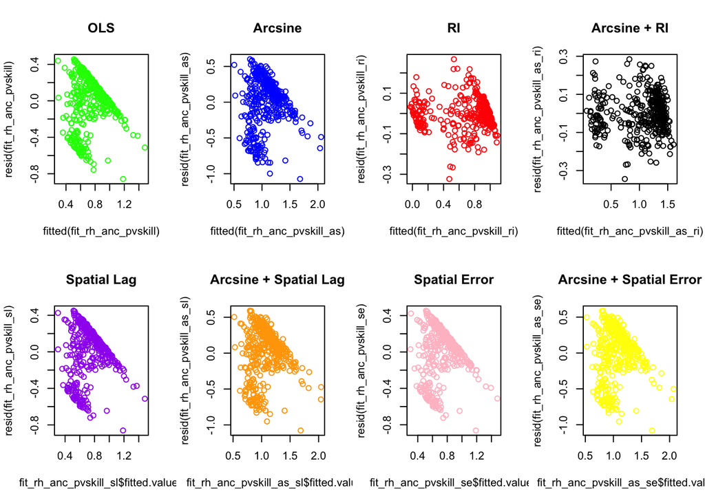

```r
par(mfrow = c(2, 4))
plot(fitted(fit_rh_anc_pvskill), resid(fit_rh_anc_pvskill), col = 'green', main = 'OLS')
plot(fitted(fit_rh_anc_pvskill_as), resid(fit_rh_anc_pvskill_as), col = 'blue', main = 'Arcsine')
plot(fitted(fit_rh_anc_pvskill_ri), resid(fit_rh_anc_pvskill_ri), col = 'red', main = 'RI')
plot(fitted(fit_rh_anc_pvskill_as_ri), resid(fit_rh_anc_pvskill_as_ri), col = 'black', main = 'Arcsine + RI')
plot(fit_rh_anc_pvskill_sl$fitted.values, resid(fit_rh_anc_pvskill_sl), col = 'purple', main = 'Spatial Lag')
plot(fit_rh_anc_pvskill_as_sl$fitted.values, resid(fit_rh_anc_pvskill_as_sl), col = 'orange', main = 'Arcsine + Spatial Lag')
plot(fit_rh_anc_pvskill_se$fitted.values, resid(fit_rh_anc_pvskill_se), col = 'pink', main = 'Spatial Error')
plot(fit_rh_anc_pvskill_as_se$fitted.values, resid(fit_rh_anc_pvskill_as_se), col = 'yellow', main = 'Arcsine + Spatial Error')
```

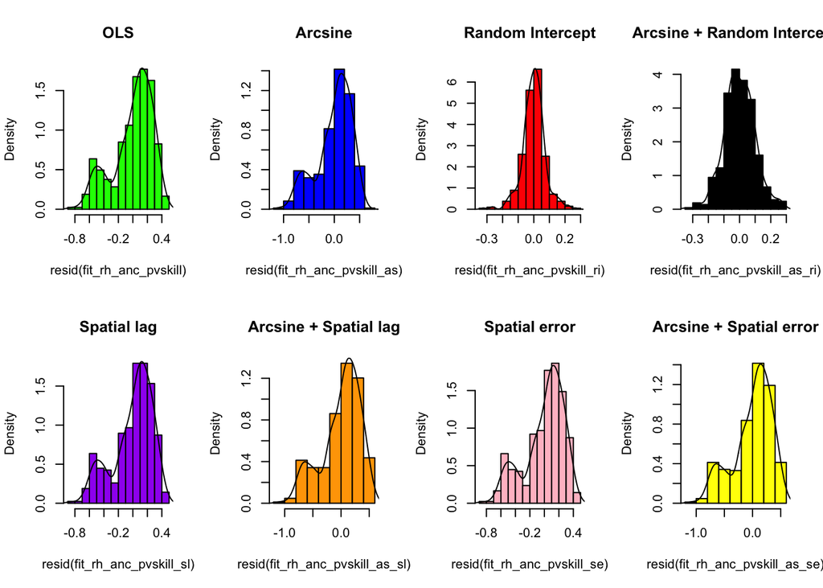

```r
par(mfrow = c(2, 4))
hist(resid(fit_rh_anc_pvskill),
     main = "OLS", prob=TRUE, col = 'green')
lines(density(resid(fit_rh_anc_pvskill)))
hist(resid(fit_rh_anc_pvskill_as),
     main = "Arcsine", prob=TRUE, col = 'blue')
lines(density(resid(fit_rh_anc_pvskill_as)))
hist(resid(fit_rh_anc_pvskill_ri),
     main = "Random Intercept", prob=TRUE, col = 'red')
lines(density(resid(fit_rh_anc_pvskill_ri)))
hist(resid(fit_rh_anc_pvskill_as_ri),
     main = "Arcsine + Random Intercept", prob=TRUE, col = 'black')
lines(density(resid(fit_rh_anc_pvskill_as_ri)))
hist(resid(fit_rh_anc_pvskill_sl),
     main = "Spatial lag", prob=TRUE, col = 'purple')
lines(density(resid(fit_rh_anc_pvskill_sl)))
hist(resid(fit_rh_anc_pvskill_as_sl),
     main = "Arcsine + Spatial lag", prob=TRUE, col = 'orange')
lines(density(resid(fit_rh_anc_pvskill_as_sl)))
hist(resid(fit_rh_anc_pvskill_se),
     main = "Spatial error", prob=TRUE, col = 'pink')
lines(density(residuals(fit_rh_anc_pvskill_se)))
hist(resid(fit_rh_anc_pvskill_as_se),
     main = "Arcsine + Spatial error", prob=TRUE, col = 'yellow')
lines(density(resid(fit_rh_anc_pvskill_as_se)))
```

It appears that the random intercept leads to most normally looking residuals. But are they normally distributed?

```r
ks.test(resid(fit_rh_anc_pvskill_as), "pnorm")
```

```
##
##  Asymptotic one-sample Kolmogorov-Smirnov test
##
## data:  resid(fit_rh_anc_pvskill_as)
## D = 0.28962, p-value < 2.2e-16
## alternative hypothesis: two-sided
```

```r
ks.test(resid(fit_rh_anc_pvskill_as_ri), "pnorm")
```

```
##
##  Asymptotic one-sample Kolmogorov-Smirnov test
##
## data:  resid(fit_rh_anc_pvskill_as_ri)
## D = 0.40537, p-value < 2.2e-16
## alternative hypothesis: two-sided
```

Even the most “normal” looking residuals don’t seem to be normally distributed, which we would agree to recalling the plot fitted vs. residuals from above.

We now try to quantify the model fit by looking at the AICs of our different models.

```r
AIC(fit_rh_anc_pvskill, fit_rh_anc_pvskill_as, fit_rh_anc_pvskill_ri, fit_rh_anc_pvskill_as_ri, fit_rh_anc_pvskill_sl, fit_rh_anc_pvskill_as_sl, fit_rh_anc_pvskill_se, fit_rh_anc_pvskill_as_se)
```

|  | df | AIC |
| --- | --- | --- |
| fit_rh_anc_pvskill | 27 | 158.8751 |
| fit_rh_anc_pvskill_as | 27 | 354.5027 |
| fit_rh_anc_pvskill_ri | 28 | -727.6366 |
| fit_rh_anc_pvskill_as_ri | 28 | -488.5743 |
| fit_rh_anc_pvskill_sl | 28 | 156.8167 |
| fit_rh_anc_pvskill_as_sl | 28 | 352.0358 |
| fit_rh_anc_pvskill_se | 28 | 157.3127 |
| fit_rh_anc_pvskill_as_se | 28 | 352.2542 |

Heavily skewed:

```r
AIC(fit_fp_know_mod, fit_fp_know_mod_as, fit_fp_know_mod_ri, fit_fp_know_mod_as_ri, fit_fp_know_mod_sl, fit_fp_know_mod_as_sl, fit_fp_know_mod_se, fit_fp_know_mod_as_se)
```

|  | df | AIC |
| --- | --- | --- |
| fit_fp_know_mod | 27 | -1240.8312 |
| fit_fp_know_mod_as | 27 | -778.0364 |
| fit_fp_know_mod_ri | 28 | -1214.2009 |
| fit_fp_know_mod_as_ri | 28 | -818.9799 |
| fit_fp_know_mod_sl | 28 | -1238.8312 |
| fit_fp_know_mod_as_sl | 28 | -776.6858 |
| fit_fp_know_mod_se | 28 | -1239.5887 |
| fit_fp_know_mod_as_se | 28 | -777.7010 |

Here, the difference is even more pronounced. In addition, the standard OLS appears to perform best, which is somehow odd.

```r
AIC(fit_fp_message_noneof3, fit_fp_message_noneof3_as, fit_fp_message_noneof3_ri, fit_fp_message_noneof3_as_ri, fit_fp_message_noneof3_sl, fit_fp_message_noneof3_as_sl, fit_fp_message_noneof3_se, fit_fp_message_noneof3_as_se)
```

|  | df | AIC |
| --- | --- | --- |
| fit_fp_message_noneof3 | 27 | -295.2535 |
| fit_fp_message_noneof3_as | 27 | -217.1979 |
| fit_fp_message_noneof3_ri | 28 | -583.7447 |
| fit_fp_message_noneof3_as_ri | 28 | -502.5336 |
| fit_fp_message_noneof3_sl | 28 | -310.4497 |
| fit_fp_message_noneof3_as_sl | 28 | -232.7387 |
| fit_fp_message_noneof3_se | 28 | -306.4364 |
| fit_fp_message_noneof3_as_se | 28 | -228.6132 |

Here, again the RI model seems to perform best, although again not the arcsine-transformed one. Let’s compare across outcomes for the random intercept:

```r
AIC(fit_ch_allvac_either_ri, fit_ch_novac_either_ri,  fit_rh_anc_pv_ri, fit_rh_anc_pvskill_ri, fit_fp_know_mod_ri, fit_nt_bf_ever_ri, fit_fp_message_noneof3_ri)
```

|  | df | AIC |
| --- | --- | --- |
| fit_ch_allvac_either_ri | 28 | -508.7900 |
| fit_ch_novac_either_ri | 28 | -1033.6044 |
| fit_rh_anc_pv_ri | 28 | -975.2772 |
| fit_rh_anc_pvskill_ri | 28 | -727.6366 |
| fit_fp_know_mod_ri | 28 | -1214.2009 |
| fit_nt_bf_ever_ri | 28 | -1622.6077 |
| fit_fp_message_noneof3_ri | 28 | -583.7447 |

We now reiterate Moran’s I for the residuals.

### Spatial autocorrelation of residuals

```r
moran_res <- data.frame()

# loop through a distance vector d ranging from 50 to 2000 m
dist_start = 1
dist_stop = 50
dist_step = 1

for (d in seq(dist_start, dist_stop, dist_step)) {

  nb_w <- geodat %>%
    st_centroid() %>%
    dnearneigh(., d1 = 0, d2 = d, longlat = T) %>%
    nb2listw(., style = "W", zero.policy = TRUE)

  for(filename in c('fit_rh_anc_pvskill', 'fit_rh_anc_pvskill_as', 'fit_rh_anc_pvskill_ri', 'fit_rh_anc_pvskill_as_ri', 'fit_rh_anc_pvskill_sl', 'fit_rh_anc_pvskill_as_sl',
             'fit_rh_anc_pvskill_se', 'fit_rh_anc_pvskill_as_se')){

    i <- get(filename)

  moran_test <- moran.mc(resid(i), nb_w, nsim = 999, zero.policy = TRUE)

  moran_res <- data.frame(moran_I = moran_test$statistic,
                             dep_var = filename,
                             distance = d) %>%
    bind_rows(moran_res)

  }
  print(paste0(d, ' of ',dist_stop))
}
```

[output not shown]

[output not shown]

[output not shown]

[output not shown]

[output not shown]

[output not shown]

[output not shown]

[output not shown]

[output not shown]

[output not shown]

[output not shown]

[output not shown]

[output not shown]

[output not shown]

[output not shown]

[output not shown]

[output not shown]

[output not shown]

[output not shown]

[output not shown]

[output not shown]

[output not shown]

[output not shown]

[output not shown]

[output not shown]

[output not shown]

[output not shown]

[output not shown]

[output not shown]

[output not shown]

[output not shown]

[output not shown]

[output not shown]

[output not shown]

[output not shown]

[output not shown]

[output not shown]

[output not shown]

[output not shown]

[output not shown]

[output not shown]

[output not shown]

[output not shown]

[output not shown]

[output not shown]

[output not shown]

[output not shown]

[output not shown]

[output not shown]

[output not shown]

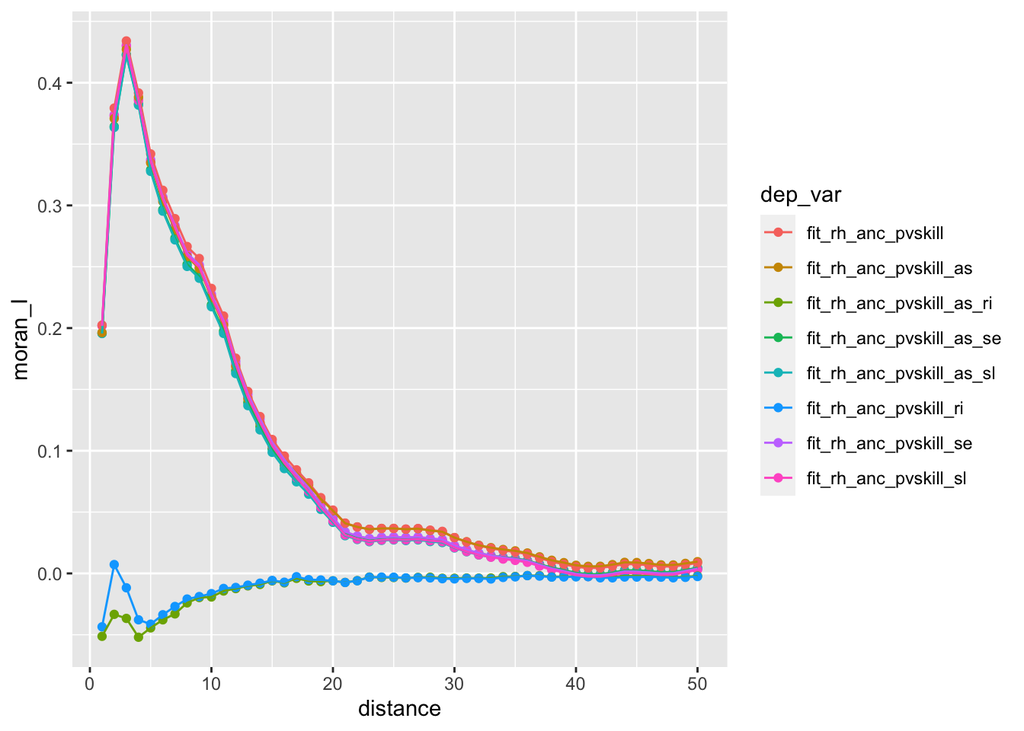

```r
ggplot(moran_res, aes(x = distance, y = moran_I, col=dep_var)) +
  geom_point() +
  geom_line()
```

The random intercept seems to account for most of the spatial autocorrelation for that variable. But does it hold across variables?

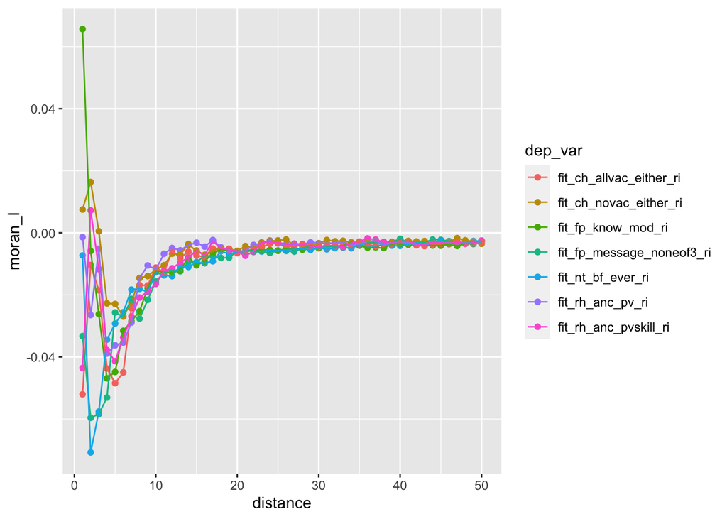

```r
moran_res <- data.frame()

# loop through a distance vector d ranging from 50 to 2000 m
dist_start = 1
dist_stop = 50
dist_step = 1

for (d in seq(dist_start, dist_stop, dist_step)) {

  nb_w <- geodat %>%
    st_centroid() %>%
    dnearneigh(., d1 = 0, d2 = d, longlat = T) %>%
    nb2listw(., style = "W", zero.policy = TRUE)

  for(filename in c('fit_ch_allvac_either_ri', 'fit_ch_novac_either_ri', 'fit_rh_anc_pv_ri', 'fit_rh_anc_pvskill_ri', 'fit_fp_know_mod_ri', 'fit_nt_bf_ever_ri', 'fit_fp_message_noneof3_ri')){

    i <- get(filename)

  moran_test <- moran.mc(resid(i), nb_w, nsim = 999, zero.policy = TRUE)

  moran_res <- data.frame(moran_I = moran_test$statistic,
                             dep_var = filename,
                             distance = d) %>%
    bind_rows(moran_res)

  }
}

ggplot(moran_res, aes(x = distance, y = moran_I, col=dep_var)) +
  geom_point() +
  geom_line()
```

As a comparison, we run the same analysis for the OLS.

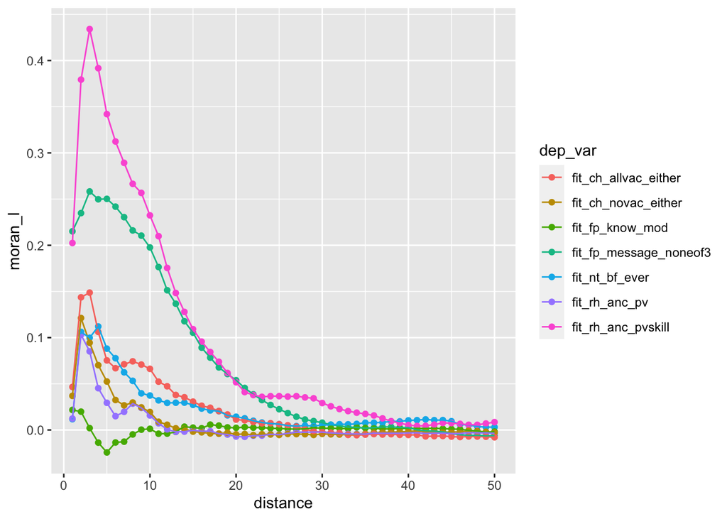

```r
moran_res <- data.frame()

# loop through a distance vector d ranging from 50 to 2000 m
dist_start = 1
dist_stop = 50
dist_step = 1

for (d in seq(dist_start, dist_stop, dist_step)) {

  nb_w <- geodat %>%
    st_centroid() %>%
    dnearneigh(., d1 = 0, d2 = d, longlat = T) %>%
    nb2listw(., style = "W", zero.policy = TRUE)

  for(filename in c('fit_ch_allvac_either', 'fit_ch_novac_either', 'fit_rh_anc_pv', 'fit_rh_anc_pvskill', 'fit_fp_know_mod', 'fit_nt_bf_ever', 'fit_fp_message_noneof3')){

    i <- get(filename)

  moran_test <- moran.mc(resid(i), nb_w, nsim = 999, zero.policy = TRUE)

  moran_res <- data.frame(moran_I = moran_test$statistic,
                             dep_var = filename,
                             distance = d) %>%
    bind_rows(moran_res)

  }
}

ggplot(moran_res, aes(x = distance, y = moran_I, col=dep_var)) +
  geom_point() +
  geom_line()
```

### Looking at effects

Since most spatial autocorrelation is captured via the random intercept, we look at corresponding regression tables across health outcomes.

```r
tab_model(fit_ch_allvac_either_ri, fit_ch_allvac_either_as_ri, fit_ch_novac_either_ri, fit_ch_novac_either_as_ri, fit_rh_anc_pv_ri, fit_rh_anc_pv_as_ri, fit_rh_anc_pvskill_ri, fit_rh_anc_pvskill_as_ri, fit_fp_know_mod_ri, fit_fp_know_mod_as_ri, fit_nt_bf_ever_ri, fit_nt_bf_ever_as_ri, fit_fp_message_noneof3_ri,fit_fp_message_noneof3_as_ri)
```

|  | ch_allvac_either |  |  | asin(sqrt(ch_allvac_either)) |  |  | ch_novac_either |  |  | asin(sqrt(ch_novac_either)) |  |  | rh_anc_pv |  |  | asin(sqrt(rh_anc_pv)) |  |  | rh_anc_pvskill |  |  | asin(sqrt(rh_anc_pvskill)) |  |  | fp_know_mod |  |  | asin(sqrt(fp_know_mod)) |  | … |
| --- | --- | --- | --- | --- | --- | --- | --- | --- | --- | --- | --- | --- | --- | --- | --- | --- | --- | --- | --- | --- | --- | --- | --- | --- | --- | --- | --- | --- | --- | --- |
| Predictors | Estimates | CI | p | Estimates | CI | p | Estimates | CI | p | Estimates | CI | p | Estimates | CI | p | Estimates | CI | p | Estimates | CI | p | Estimates | CI | p | Estimates | CI | p | Estimates | CI | … |
| (Intercept) | 35.19 | -60.83 – 131.20 | 0.472 | 28.77 | -80.04 – 137.58 | 0.603 | -19.40 | -69.73 – 30.93 | 0.449 | 20.66 | -64.06 – 105.38 | 0.632 | 60.60 | 6.46 – 114.73 | **0.028** | 82.37 | 2.42 – 162.32 | **0.043** | 55.03 | -14.67 – 124.73 | 0.121 | 68.82 | -25.80 – 163.44 | 0.154 | 24.85 | -15.74 – 65.44 | 0.229 | 23.65 | -42.64 – 89.95 | … |
| Mean SCI without Self | -0.12 | -0.48 – 0.23 | 0.501 | -0.14 | -0.54 – 0.27 | 0.505 | -0.13 | -0.32 – 0.05 | 0.160 | -0.11 | -0.42 – 0.21 | 0.497 | 0.38 | 0.18 – 0.58 | **<0.001** | 0.38 | 0.08 – 0.68 | **0.012** | 0.45 | 0.19 – 0.71 | **0.001** | 0.33 | -0.02 – 0.69 | 0.064 | 0.00 | -0.15 – 0.15 | 0.993 | 0.12 | -0.13 – 0.36 | … |
| Ratio selfloop to africa | -0.00 | -0.02 – 0.01 | 0.932 | -0.00 | -0.02 – 0.02 | 0.924 | -0.00 | -0.01 – 0.01 | 0.507 | -0.01 | -0.02 – 0.01 | 0.384 | 0.00 | -0.01 – 0.01 | 0.738 | 0.00 | -0.01 – 0.01 | 0.849 | 0.01 | -0.00 – 0.02 | 0.262 | 0.00 | -0.01 – 0.02 | 0.585 | -0.00 | -0.01 – 0.01 | 0.799 | -0.01 | -0.02 – 0.01 | … |
| Ratio SCI low hi africa | 0.03 | -0.02 – 0.08 | 0.200 | 0.05 | -0.01 – 0.10 | 0.085 | 0.00 | -0.02 – 0.02 | 0.998 | -0.01 | -0.05 – 0.03 | 0.759 | 0.00 | -0.02 – 0.03 | 0.810 | 0.00 | -0.03 – 0.04 | 0.788 | -0.02 | -0.07 – 0.02 | 0.366 | -0.03 | -0.09 – 0.03 | 0.321 | -0.00 | -0.02 – 0.01 | 0.790 | -0.00 | -0.03 – 0.02 | … |
| Ratio SCI high hi africa | 0.01 | -0.01 – 0.03 | 0.213 | 0.02 | -0.00 – 0.04 | 0.118 | -0.01 | -0.02 – 0.00 | 0.172 | -0.00 | -0.02 – 0.02 | 0.837 | 0.02 | 0.01 – 0.03 | **<0.001** | 0.03 | 0.01 – 0.05 | **0.001** | 0.03 | 0.01 – 0.04 | **0.003** | 0.02 | -0.00 – 0.04 | 0.078 | 0.00 | -0.00 – 0.01 | 0.368 | 0.01 | -0.00 – 0.02 | … |
| poorest | -0.01 | -0.12 – 0.10 | 0.865 | -0.00 | -0.13 – 0.12 | 0.966 | 0.00 | -0.05 – 0.06 | 0.931 | -0.00 | -0.10 – 0.09 | 0.926 | -0.01 | -0.07 – 0.05 | 0.729 | -0.04 | -0.13 – 0.05 | 0.381 | 0.06 | -0.02 – 0.14 | 0.137 | 0.05 | -0.06 – 0.16 | 0.368 | -0.01 | -0.05 – 0.04 | 0.736 | -0.02 | -0.09 – 0.05 | … |
| poorer | 0.05 | -0.12 – 0.23 | 0.530 | 0.07 | -0.13 – 0.26 | 0.502 | -0.02 | -0.11 – 0.07 | 0.646 | -0.09 | -0.24 – 0.06 | 0.234 | 0.10 | 0.01 – 0.20 | **0.035** | 0.13 | -0.01 – 0.27 | 0.069 | 0.13 | 0.01 – 0.26 | **0.037** | 0.18 | 0.02 – 0.35 | **0.033** | 0.01 | -0.07 – 0.08 | 0.872 | 0.10 | -0.02 – 0.21 | … |
| female | 2.42 | -1.72 – 6.57 | 0.251 | 2.48 | -2.22 – 7.18 | 0.300 | -1.64 | -3.82 – 0.53 | 0.138 | -3.19 | -6.85 – 0.47 | 0.087 | 3.79 | 1.45 – 6.13 | **0.002** | 4.87 | 1.42 – 8.33 | **0.006** | 2.31 | -0.70 – 5.31 | 0.132 | 2.17 | -1.91 – 6.25 | 0.296 | -0.35 | -2.11 – 1.41 | 0.693 | -0.28 | -3.15 – 2.59 | … |
| secondary or higher | 0.77 | 0.04 – 1.50 | **0.039** | 1.04 | 0.21 – 1.87 | **0.014** | -0.96 | -1.34 – -0.58 | **<0.001** | -1.29 | -1.94 – -0.65 | **<0.001** | 0.93 | 0.52 – 1.34 | **<0.001** | 1.20 | 0.60 – 1.81 | **<0.001** | 1.41 | 0.87 – 1.95 | **<0.001** | 1.57 | 0.84 – 2.30 | **<0.001** | 0.38 | 0.08 – 0.68 | **0.013** | 0.71 | 0.22 – 1.21 | … |
| has mobile phone yes | 0.85 | -1.70 – 3.39 | 0.514 | 0.81 | -2.08 – 3.69 | 0.583 | -0.67 | -2.00 – 0.67 | 0.328 | -1.33 | -3.58 – 0.92 | 0.245 | 1.74 | 0.30 – 3.17 | **0.018** | 2.17 | 0.05 – 4.29 | **0.045** | 0.79 | -1.06 – 2.63 | 0.402 | 0.52 | -1.99 – 3.02 | 0.686 | -0.14 | -1.22 – 0.94 | 0.796 | -0.10 | -1.86 – 1.66 | … |
| rural | 0.01 | -0.08 – 0.10 | 0.828 | 0.04 | -0.07 – 0.15 | 0.469 | -0.04 | -0.09 – 0.01 | 0.132 | -0.01 | -0.10 – 0.07 | 0.725 | 0.01 | -0.04 – 0.06 | 0.703 | 0.00 | -0.08 – 0.08 | 0.940 | -0.04 | -0.11 – 0.03 | 0.246 | -0.07 | -0.16 – 0.03 | 0.166 | 0.07 | 0.03 – 0.11 | **0.001** | 0.11 | 0.05 – 0.18 | … |
| X 0 15 | -36.47 | -132.39 – 59.45 | 0.455 | -29.86 | -138.56 – 78.84 | 0.589 | 20.50 | -29.78 – 70.77 | 0.423 | -18.29 | -102.92 – 66.34 | 0.671 | -61.95 | -116.03 – -7.87 | **0.025** | -84.07 | -163.94 – -4.21 | **0.039** | -56.00 | -125.63 – 13.63 | 0.115 | -69.63 | -164.15 – 24.89 | 0.148 | -24.05 | -64.60 – 16.50 | 0.244 | -22.76 | -88.99 – 43.46 | … |
| X 15 20 | -34.14 | -130.06 – 61.78 | 0.484 | -27.56 | -136.26 – 81.14 | 0.618 | 20.36 | -29.92 – 70.63 | 0.426 | -19.77 | -104.40 – 64.87 | 0.646 | -61.44 | -115.52 – -7.37 | **0.026** | -82.97 | -162.84 – -3.11 | **0.042** | -55.58 | -125.21 – 14.05 | 0.117 | -68.73 | -163.25 – 25.79 | 0.154 | -23.64 | -64.19 – 16.90 | 0.252 | -22.27 | -88.49 – 43.95 | … |
| X 20 25 | -38.53 | -134.50 – 57.43 | 0.430 | -32.10 | -140.85 – 76.65 | 0.562 | 21.22 | -29.08 – 71.53 | 0.407 | -16.10 | -100.78 – 68.57 | 0.709 | -62.28 | -116.39 – -8.18 | **0.024** | -84.33 | -164.23 – -4.42 | **0.039** | -55.89 | -125.54 – 13.77 | 0.116 | -68.89 | -163.45 – 25.68 | 0.153 | -23.62 | -64.19 – 16.95 | 0.253 | -21.48 | -87.73 – 44.78 | … |
| X 25 30 | -34.94 | -130.93 – 61.05 | 0.475 | -28.42 | -137.20 – 80.36 | 0.608 | 20.22 | -30.09 – 70.53 | 0.430 | -19.94 | -104.63 – 64.76 | 0.644 | -61.96 | -116.07 – -7.84 | **0.025** | -84.17 | -164.09 – -4.24 | **0.039** | -56.14 | -125.81 – 13.54 | 0.114 | -70.31 | -164.90 – 24.28 | 0.145 | -23.88 | -64.46 – 16.69 | 0.248 | -22.65 | -88.92 – 43.62 | … |
| X 30 35 | -35.51 | -131.40 – 60.39 | 0.467 | -28.96 | -137.63 – 79.71 | 0.601 | 21.45 | -28.82 – 71.71 | 0.402 | -17.80 | -102.41 – 66.82 | 0.679 | -61.71 | -115.78 – -7.65 | **0.025** | -83.14 | -162.99 – -3.30 | **0.041** | -55.45 | -125.06 – 14.16 | 0.118 | -68.26 | -162.76 – 26.23 | 0.156 | -23.98 | -64.52 – 16.55 | 0.245 | -22.34 | -88.55 – 43.86 | … |
| X 35 40 | -34.79 | -130.66 – 61.08 | 0.476 | -27.78 | -136.42 – 80.87 | 0.616 | 18.77 | -31.48 – 69.02 | 0.463 | -19.89 | -104.48 – 64.69 | 0.644 | -60.29 | -114.34 – -6.25 | **0.029** | -82.66 | -162.48 – -2.84 | **0.042** | -54.30 | -123.89 – 15.29 | 0.126 | -67.53 | -162.00 – 26.94 | 0.161 | -22.95 | -63.48 – 17.57 | 0.266 | -20.57 | -86.76 – 45.61 | … |
| X 40 45 | -36.06 | -132.06 – 59.95 | 0.461 | -29.22 | -138.01 – 79.58 | 0.598 | 19.39 | -30.94 – 69.71 | 0.449 | -21.12 | -105.83 – 63.59 | 0.624 | -61.44 | -115.57 – -7.31 | **0.026** | -83.41 | -163.35 – -3.47 | **0.041** | -55.63 | -125.31 – 14.06 | 0.117 | -69.27 | -163.87 – 25.34 | 0.151 | -23.20 | -63.79 – 17.38 | 0.262 | -21.49 | -87.78 – 44.80 | … |
| X 45 50 | -35.54 | -131.54 – 60.47 | 0.467 | -28.74 | -137.53 – 80.05 | 0.604 | 20.21 | -30.11 – 70.53 | 0.430 | -18.91 | -103.62 – 65.80 | 0.661 | -61.86 | -115.98 – -7.74 | **0.025** | -83.25 | -163.19 – -3.31 | **0.041** | -55.95 | -125.64 – 13.74 | 0.115 | -69.18 | -163.79 – 25.42 | 0.151 | -24.08 | -64.66 – 16.50 | 0.244 | -22.94 | -89.22 – 43.34 | … |
| X 50 inf | -35.61 | -131.57 – 60.35 | 0.466 | -29.05 | -137.80 – 79.69 | 0.600 | 20.68 | -29.62 – 70.98 | 0.419 | -18.66 | -103.33 – 66.01 | 0.665 | -61.93 | -116.03 – -7.83 | **0.025** | -83.83 | -163.73 – -3.93 | **0.040** | -55.42 | -125.07 – 14.24 | 0.119 | -68.55 | -163.10 – 26.01 | 0.155 | -23.93 | -64.50 – 16.63 | 0.247 | -22.34 | -88.59 – 43.92 | … |
| Mean of Night Light | -0.01 | -0.03 – 0.00 | 0.158 | -0.01 | -0.03 – 0.01 | 0.216 | 0.01 | -0.00 – 0.01 | 0.140 | 0.00 | -0.01 – 0.02 | 0.449 | -0.01 | -0.02 – 0.00 | 0.084 | -0.01 | -0.02 – 0.00 | 0.143 | 0.00 | -0.01 – 0.01 | 0.460 | 0.01 | -0.01 – 0.02 | 0.274 | -0.01 | -0.01 – -0.00 | **0.013** | -0.01 | -0.02 – 0.00 | … |
| Mean distance to major rd | -0.01 | -0.03 – 0.00 | 0.066 | -0.02 | -0.03 – -0.00 | **0.045** | 0.01 | 0.00 – 0.02 | **0.025** | 0.01 | 0.00 – 0.03 | **0.036** | -0.02 | -0.03 – -0.01 | **<0.001** | -0.02 | -0.04 – -0.01 | **<0.001** | -0.01 | -0.02 – -0.00 | **0.014** | -0.02 | -0.03 – -0.00 | **0.011** | -0.01 | -0.02 – -0.01 | **<0.001** | -0.02 | -0.03 – -0.01 | … |
| FB pntr 15to49 all | -0.03 | -0.12 – 0.06 | 0.469 | -0.03 | -0.13 – 0.07 | 0.615 | -0.01 | -0.06 – 0.04 | 0.637 | -0.01 | -0.09 – 0.07 | 0.783 | -0.01 | -0.06 – 0.04 | 0.605 | -0.02 | -0.09 – 0.05 | 0.577 | 0.03 | -0.03 – 0.10 | 0.333 | 0.04 | -0.05 – 0.13 | 0.350 | -0.02 | -0.05 – 0.02 | 0.354 | -0.03 | -0.09 – 0.03 | … |
| female × has mobile phone yes | -1.48 | -6.39 – 3.43 | 0.553 | -1.35 | -6.91 – 4.22 | 0.635 | 1.20 | -1.37 – 3.78 | 0.359 | 2.44 | -1.90 – 6.77 | 0.270 | -3.19 | -5.96 – -0.42 | **0.024** | -3.94 | -8.03 – 0.16 | 0.059 | -1.28 | -4.84 – 2.28 | 0.480 | -0.64 | -5.47 – 4.19 | 0.795 | 0.44 | -1.64 – 2.52 | 0.678 | 0.45 | -2.95 – 3.85 | … |
| Mean SCI without Self × female | 0.42 | -0.25 – 1.10 | 0.218 | 0.48 | -0.29 – 1.25 | 0.219 | 0.16 | -0.19 – 0.52 | 0.364 | 0.05 | -0.55 – 0.64 | 0.879 | -0.61 | -0.99 – -0.23 | **0.002** | -0.53 | -1.09 – 0.03 | 0.066 | -0.75 | -1.24 – -0.26 | **0.003** | -0.50 | -1.17 – 0.16 | 0.139 | 0.06 | -0.23 – 0.35 | 0.678 | -0.10 | -0.57 – 0.36 | … |
| Mean SCI without Self × has mobile phone yes | -0.15 | -0.24 – -0.06 | **0.001** | -0.17 | -0.27 – -0.07 | **0.001** | 0.06 | 0.02 – 0.11 | **0.006** | 0.10 | 0.03 – 0.18 | **0.009** | -0.08 | -0.13 – -0.03 | **0.002** | -0.11 | -0.18 – -0.04 | **0.002** | -0.07 | -0.13 – -0.01 | **0.032** | -0.07 | -0.15 – 0.02 | 0.124 | -0.04 | -0.07 – -0.00 | **0.040** | -0.06 | -0.12 – 0.00 | … |
| Random Effects |  |  |  |  |  |  |  |  |  |  |  |  |  |  |  |  |  |  |  |  |  |  |  |  |  |  |  |  |  | … |
| σ<sup>2</sup> | 0.01 |  |  | 0.01 |  |  | 0.00 |  |  | 0.01 |  |  | 0.00 |  |  | 0.01 |  |  | 0.01 |  |  | 0.01 |  |  | 0.00 |  |  | 0.01 |  | … |
| τ<sub>00</sub> | 0.04 <sub>iso3</sub> |  |  | 0.05 <sub>iso3</sub> |  |  | 0.01 <sub>iso3</sub> |  |  | 0.02 <sub>iso3</sub> |  |  | 0.01 <sub>iso3</sub> |  |  | 0.02 <sub>iso3</sub> |  |  | 0.09 <sub>iso3</sub> |  |  | 0.14 <sub>iso3</sub> |  |  | 0.00 <sub>iso3</sub> |  |  | 0.01 <sub>iso3</sub> |  | … |
| ICC | 0.77 |  |  | 0.76 |  |  | 0.66 |  |  | 0.72 |  |  | 0.66 |  |  | 0.70 |  |  | 0.94 |  |  | 0.93 |  |  | 0.50 |  |  | 0.59 |  | … |
| N | 28 <sub>iso3</sub> |  |  | 28 <sub>iso3</sub> |  |  | 28 <sub>iso3</sub> |  |  | 28 <sub>iso3</sub> |  |  | 28 <sub>iso3</sub> |  |  | 28 <sub>iso3</sub> |  |  | 28 <sub>iso3</sub> |  |  | 28 <sub>iso3</sub> |  |  | 28 <sub>iso3</sub> |  |  | 28 <sub>iso3</sub> |  | … |
| Observations | 424 |  |  | 424 |  |  | 424 |  |  | 424 |  |  | 424 |  |  | 424 |  |  | 424 |  |  | 424 |  |  | 424 |  |  | 424 |  | … |
| Marginal R<sup>2</sup> / Conditional R<sup>2</sup> | 0.149 / 0.806 |  |  | 0.160 / 0.803 |  |  | 0.226 / 0.736 |  |  | 0.194 / 0.773 |  |  | 0.330 / 0.775 |  |  | 0.290 / 0.785 |  |  | 0.116 / 0.947 |  |  | 0.123 / 0.938 |  |  | 0.277 / 0.637 |  |  | 0.288 / 0.709 |  | … |